# Cognitive Psychology and Its Implications.Anderson2010.7e.认知心理学及其启示

### 前额的执行控制部位

我们已经看到顶叶皮层对实现知觉注意很重要。有证据表明，前额的一些区域在指挥中枢认知方面特别重要。这个功能通常被称为执行控制 （executive control）。前额皮层是位于运动前区（运动前区是彩色插页1.1中的6区）前面的额叶皮层。正如顶叶受损会导致知觉通道的注意缺陷那样，前额叶受损会导致执行控制缺陷。有这种损伤的患者似乎经常完全受刺激驱动，无法按照他们的意愿去控制自己的行为。一位患者看见桌上有一把梳子可能会随手拿起它开始梳理头发；另一位患者看见一副眼镜，即使自己已经戴了眼镜也可能会再将它戴上。前额叶受损的患者在斯特鲁普任务中表现出明显的缺陷，他们常常不可抑制地去阅读单词，而不是去命名颜色（Janer & Pardo，1991）。

前额的两个区域似乎对执行控制特别重要。一个是背外侧前额叶 （dorsolateral prefrontal cortex，DLPFC），它是前额皮层靠上的部分（参见图3.1）。之所以称其为背外侧是因为它的位置较高（位于背面）并且位于侧面。第二个区是前扣带回 （anterior cingulated cortex，ACC），它是一个在脑表面皮层以下、沿脑部中线的结构。它是在可见表层下折叠着的皮层的一部分。DLPFC似乎对确定意向和控制行为特别重要。例如，在同时执行结果如图3.21和图3.22所报告的那类双重任务时，这一部分会高度活跃（Szameitat，Schubert，Muller，& von Cramon，2002）。ACC似乎在人们必须监控相互竞争的倾向之间的冲突时特别活跃。例如，脑成像研究表明在斯特鲁普实验中，当单词所用墨水的颜色与单词意义相冲突，而被试必须说出墨水的颜色时，这个区域会高度活跃（J．V．Pardo，P．J．Pardo，Janer，& Raichle，1990）。

ACC与许多任务中的认知控制有紧密的关系。例如，似乎随着ACC的发育，儿童也发展出了更多的认知控制功能。ACC的激活量与儿童完成需要认知控制的任务时的成绩具有相关性（Casey et al.，1997a）。从发展的角度来看，成绩与ACC的绝对体积之间也存在着正相关（Casey et al.，1997b）。用于证明儿童认知控制发展的良好实验范式是“西蒙说”任务 <sup>(11)</sup> 。在一项研究中，琼斯、罗斯巴特和波斯纳（Jones，Rothbart & Posner，2003）让儿童接收来自两个玩具娃娃的指示——一只小熊和一只小象。指导语可以是这样的：“小象说，‘摸你的鼻子。’”要求儿童听从一个娃娃（行动娃娃）的指示，并忽视另一个娃娃（抑制娃娃）的指示。所有儿童都成功地听从了行动娃娃的指示，但是许多儿童很难忽视抑制娃娃的指示。从36个月到48个月，儿童忽视抑制娃娃的成功率从22％逐渐上升到91％。一些儿童利用调控性自我对话来控制自己的行为，正如卢里亚（Luria，1961）所提出的著名观点。但是他们用的策略还有诸如坐在他们的手上或者扭曲他们的行为，指向耳朵而不是鼻子。

评价前额区域对认知控制重要性的另一个方法是将人类的表现与其他灵长类进行比较。如第一章所述，从灵长类到人类的一个主要进化维度就是前额区域大小的增加。灵长类经过训练能够完成许多人类的任务，所以两者之间可以进行谨慎的比较。其中一种任务是斯特鲁普任务的变体，即给被试呈现一行数字（例如，五个3）和空格，要求说出目标数字的个数，而不是读出数字。图3.26是此类任务的一个例子，它与原始斯特鲁普任务（彩色插页3.2）的模式相同：试着说出每行数字的个数或者试着读出每行中的数字是什么。在这种情况下，数字命名对个数产生了较强的干扰（Windes，1968）。这一实验范式曾用于比较人类和恒河猴之间的斯特鲁普干扰效应。实验中的恒河猴也被训练学会使用数字（Washburn，1994；见表3.1）。两组被试都看到两组数列，并要求他们指出哪组数列中的数字多，而不管数字是什么。基线任务是哪组字母数量更多，通过与基线的比较，人类和猴子都在数字与数量一致时成绩较好，而数字与数量不一致时成绩较差（如图3.26）。两类被试表现出了相似的反应时效应，但是人类被试在不一致条件下的错误率为3％，而猴子的错误率为27％。猴子的表现类似于前额叶损伤的病人的表现。

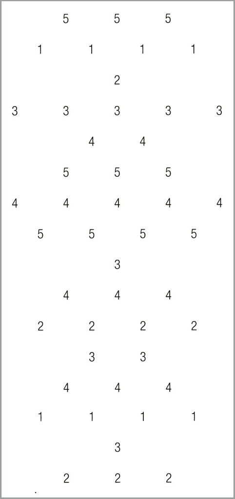

图3.26 与颜色斯特鲁普任务（见彩色插页3.2 ）相似的数字斯特鲁普任务。

表3.1 不同物种和条件下的平均反应时和正确率

| 条件 | 正确率（％） | 反应时（毫秒） |
| --- | --- | --- |
|  | 恒河猴（N＝6） |  |
| 一致数字 | 92 | 676 |
| 基线（字母） | 86 | 735 |
| 不一致数字 | 73 | 829 |
|  | 人类被试（N＝28） |  |
| 一致数字 | 99 | 584 |
| 基线（字母） | 99 | 613 |
| 不一致数字 | 97 | 661 |

◎前额叶区，尤其是DLPFC和ACC，在执行控制中起主要作用。

## 结论

认知心理学对注意问题的认识有个渐变的过程。长期以来，它的隐含假设体现在一个多世纪前威廉·詹姆斯（William James，1890）的这段著名的引文中：

人人都知道注意是什么。注意就是通过心理以清晰而鲜明的形式从看来同时有可能的几个物体或思路中取其一的过程。意识的集中和专注是它的本质。它意味着从某些事物中撤出以便有效地处理其他事物（pp.403～404）。

这一引文有两个特征反映了曾经有过的一些关于注意的观点。首先，注意与意识紧密相关——除非我们意识到某个事物，否则我们不可能注意它。其次，注意和意识一样，是个单一的系统。现在认知心理学越来越认识到注意是在无意识水平下运作的。例如，人们通常不会意识到他们已将眼睛转向了何处。相应地，认知心理学逐渐认识到注意是多方面的（例如，Pashler，1995）。我们已经看到，将听觉注意与视觉注意区分开、将知觉加工中的注意与执行控制中的注意以及与产生反应中的注意区分开是有道理的。脑由许多平行加工的系统所构成，包括各种知觉系统、各种运动系统和中枢认知。每一个这样的平行系统似乎都存在瓶颈，即系统必须集中加工单一事情的地方。最好将注意设想为一个过程，通过这个过程，系统从潜在地相互竞争的若干信息加工需求中，一次选择一个来处理。任务之间的干扰量是这些任务对同一系统的需求的重叠程度的函数。

### 思考题

1. 本章讨论了听一条言语信息是如何使加工另一条言语信息变得困难的。你认为一边开车一边打电话会使其他声音，如汽车喇叭声更不容易被注意到吗？
2. 哪种搜索会产生较强的顶叶激活？搜索图3.13a中的T还是搜索图3.13b中的T？
3. 描述有利于人们注意物体而不是空间位置的一些情况，以及有利于人们注意空间位置而不是物体的一些情况。
4. 我们已经讨论了自动化行为如何强行植入其他行为，以及驾驶行为的某些方面是如何自动化的。思考这样的情景，一名司机有着娴熟的驾驶技术，并且多年的驾驶经验使得他在一些方面形成了自动化行为。你能举出一些例子表明自动化的驾驶行为会对车里乘客的行为产生影响吗？这能有助于解释为什么与车里的乘客谈话不会像打电话那样分散注意吗？

### 关键术语

顺序瓶颈

早期选择理论

后期选择理论

注意

目标导向注意

刺激驱动注意

双耳分听任务

过滤器理论

衰减理论

捆绑问题

特征整合理论

错觉关联

基于空间的注意

基于物体的注意

返回抑制

完全时间分享

中枢瓶颈

自动化

斯特鲁普效应

执行控制

背外侧前额叶皮层

前扣带回皮层

(1) 又译为序列瓶颈、系列瓶颈，指只能将事情按顺序一件一件去做的地方。——译者注

(2) 原文是‘points’。对于是什么‘points’，作者在email中说明它是信息加工流中的点（‘it really refers to points in the information-processing stream，for instance going from low-level visual processing to object recognition’）。——译者注

(3) 鼓手（包括我的儿子）特别善于做此事——而我绝对不是一个鼓手。这说明实际问题可能出在运动的时间协调上。

(4) 音调由声音的频率决定。

(5) 这就是当橄榄球的四分卫球员在传球时所应做到的，这样他们就不至于“丢失”目标接手的位置。

(6) 指执行双重任务时被试给出第一个答案的时间（可以是加法题答案，也可以是乘法题答案，取决于被试）。——译者注

(7) 参见本章听觉注意部分。——译者注

(8) 当进一步训练被试，要求他们记住听写的内容时，他们也能回忆出这些信息。

(9) 很多时候直接称为Stroop效应。——译者注

(10) 本实验细节补充说明如下：有四种相互间有明显区别的随机的多边形（不包括长方形），分别被命名为绿、粉、橙、蓝等四种颜色名。而这四种多边形本身又可以具有以上的四种颜色之一。例如，有一个多边形，它的名字是“绿”，它本身的颜色是粉色的。当学习图形所对应的颜色名时，图形是白色的，背景是黑色的。当用于控制条件时，图形本身的颜色也是白色的。长方形只用于控制条件，不对应任何颜色名。——译者注

(11) ‘西蒙说’（Simon says）是一种美国常见的儿童游戏，要求按指示做一个简单动作，例如摸鼻子、指耳朵或蹦一下。但是指示有两种，如果开头有‘西蒙说’（例如‘西蒙说摸鼻子’），你就得执行（摸鼻子）；如果开头没有‘西蒙说’（例如‘摸鼻子’）你就不执行（不做任何动作，或者做一个其他动作，例如指耳朵）。——译者注

# 第4章 心理表象

试 着回答这样两个问题：

- 你家有几扇窗户？
- 美国效忠誓词 <sup>(1)</sup> 里有多少个名词？

许多人在回答这两个问题时都有相同的体验。对于第一个问题，他们想象自己在家里转着弯数窗户。对于第二个问题，他们即使不能真的高声朗读效忠誓词，也会想象自己在念效忠誓词。在这两个例子中，他们都产生了心理表象，感知自己真的走在家里或念效忠誓词。

使用视觉表象特别重要。作为我们灵长类的遗传特质，我们的脑有很大一部分功能是视觉信息加工。因此，我们尽可能地使用这些脑结构，甚至没有外界的视觉信号输入，我们也能在头脑中产生心理表象去使用它们。一些人类最有创造性的活动都涉及视觉表象。例如，爱因斯坦声称他通过想象自己在一条光柱旁运动才发现了相对论。

这一研究领域主要的争论在于，视觉表象背后的加工过程与前两章提到的知觉和注意的加工过程有多大程度的相似。一些研究者（如，Pylyshyn，1973）认为我们从事一项活动如描绘自己家房子的窗户时产生的知觉体验是一种副现象 （epiphenomenon）；也就是说，这是一种对信息加工没有任何功能性作用的心理体验。哲学家丹尼尔·丹尼特（Daniel Dennett，1969）也认为心理表象是一种副现象，即心理表象的知觉成分不会以任何方式真的发生作用：

想想老虎和它身上的斑纹。我能梦见、想象或看到一只有斑纹的老虎，但是这只老虎身上一定要有特定数目的斑纹吗？如果看到或想象会产生一个心理表象，那么表象中的这只老虎一定——遵循图像的一般原则——有确定数量的斑纹，并且一个人应该能够回答出这样的问题：“多于10条？”“少于20条？”（p.136）

丹尼特认为如果我们真的在心理表象中看到一只老虎，那么我们应该能够数出它身上的斑纹，就好像我们真的看着一只老虎那样。因为我们无法凭心理表象数出老虎的斑纹数，所以我们并没有真正的知觉体验。这种说法并不能令人信服，但却代表了一些人对心理表象确实有知觉特征的论断的不满。

本章综述了一些实验证据来说明心理表象对信息加工发生作用的方式。我们将心理表象 （mental imagery）广义地定义为在没有外在知觉信息来源的情况下对类似知觉信息的加工。我们将思考以下问题：

- 我们如何加工心理表象中的信息？
- 表象加工是怎样与知觉加工相关联的？
- 哪些脑区参与心理表象？
- 我们如何建立周围环境的心理表象，并利用它们在环境中穿行？

## 言语表象与视觉表象

越来越多的认知神经科学证据表明有几个不同的脑区参与到表象的加工中。这些证据既来自对不同部位脑损伤病人的研究，也来自对正常人在完成各种表象任务时脑激活情况的研究。在脑加工表象时的激活模式的早期研究中，罗兰和弗雷伯格（Roland & Friberg，1985）发现的许多脑区得到了后续的研究。他们安排被试在心里背诵押韵的广告语（word jingle） <sup>(2)</sup> ，或者在心里预演在住处附近的街道上找路。实验测量的是大脑皮层不同部位的血流变化。图4.1所示的就是他们发现的主要区域。当被试默诵押韵广告语时，布洛卡区附近的前额叶皮层和大脑皮层后部的威尔尼克区附近的颞顶联合区都得到了激活。正如我们在第1章所看到的那样，这些区域损伤的病人会表现出语言加工的缺陷。当被试进行视觉任务时，顶叶、枕叶和颞叶皮层都有所激活。正如我们在第2章和第3章所看到的，所有这些区域都与视知觉和注意有关。当人们加工言语或视觉信息的表象时，所激活的一些区域与加工真实的言语或视觉信息时相同。

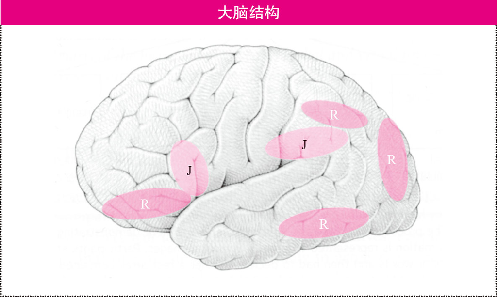

图4.1 罗兰和弗雷伯格（1985）对大脑加工心理表象时的激活模式的研究。左侧大脑皮层的一些区域在被试默诵押韵的广告语（J）或者空间道路（R）时，表现出血流量增加。

桑塔（Santa，1977）所做的实验证实了视觉表象的信息表征和言语表象的信息表征之间的功能差异。桑塔的实验中有两种条件，如图4.2所示。在几何图形条件下（图4.2a），被试要学习由三个几何图形组成的项目，两个图形排列在上面，一个在下面的中间位置上。这一组图形看起来很像人脸——人们很容易将它们看成两个眼睛和一张嘴。在学习了这组图形以后，图形消失，被试不得不在他们心中保存着这些信息。随后又呈现了一组不同的图形作为测验项目。被试的任务是判断测验项目中的图形元素是否与学习项目相同，而不考虑空间位置是否有改变。因此，对于前两个测验项目，被试的答案应该是肯定的，对于后两个测验项目，被试的答案应该是否定的。桑塔感兴趣于两个肯定答案的测验项目的比较。第一个与学习项目的排列完全相同（相同结构条件）。在第二个测验项目中，图形元素是排成一条直线的（线性结构条件）。桑塔预期被试对第一个测验项目，也就是完全相同的那个项目，做出肯定判断的速度较快。因为他的假设是，在学习刺激材料时产生的视觉表象能够保存空间信息。几何图形条件下的结果见图4.3。如图所示，桑塔的预期得到了证实。当几何图形的测验项目保持了学习项目中的图形结构信息时，被试的判断速度较快。

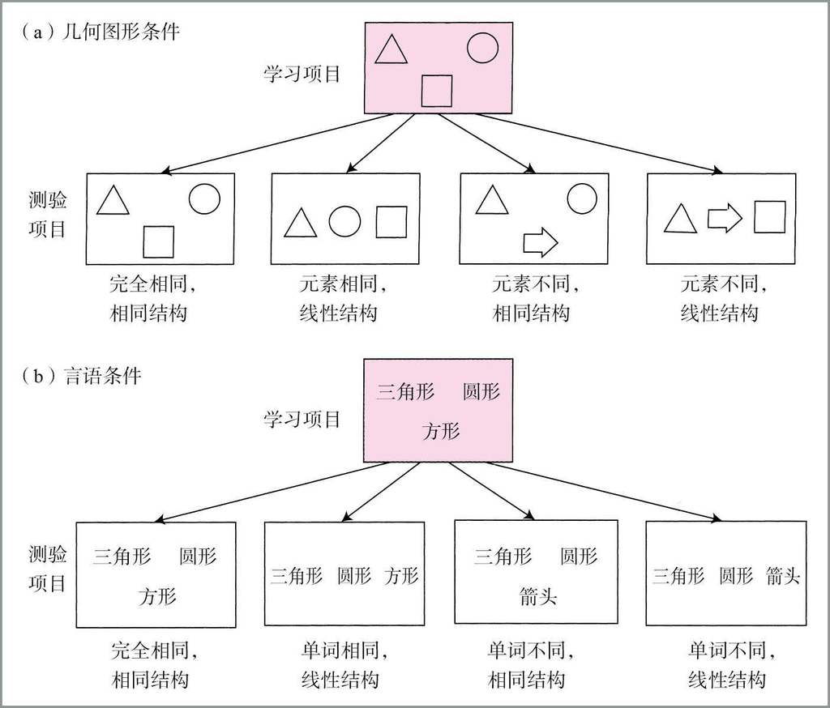

图4.2 桑塔（1977）的实验程序证实了视觉信息和言语信息在心理表象中的表征不同。被试学习一个初始的项目，或图形或单词，随后要判断测验项目是否与学习项目包含相同的元素。几何图形如（a）所示，单词如（b）所示。

几何图形条件下的结果如果与言语条件下的结果（见图4.2b）进行比较，就更为醒目了。在言语条件下，被试学习的单词组的排列与几何图形条件下完全相同。然而，因为是单词，所以学习材料不会被看成是人脸或者其他图形。桑塔推测被试会按照从左至右、从上到下的顺序阅读单词，用此信息对言语表象进行编码。

由此，对于图中所给出的学习项目，被试就编码成“三角形、圆形、方形 ”。在学习了初始项目后，立即呈现一个测验项目。被试要判断其中的单词是否与学习项目中的相同。虽然所有的测验材料都是单词组成，但是刺激呈现的方式和几何图形条件下完全相同。在单词与学习项目完全相同的两个测验项目中，一个测验项目中的单词排列与学习项目完全相同（相同结构条件），另一个测验项目中的单词排成一条直线（线性结构条件）。请注意，线性排列的单词顺序和学习材料中的单词顺序是一样的。桑塔预期，与几何图形条件不同，因为被试将单词编码为线性排列的言语表象，所以当测验项目是线性排列时被试的反应最快。如图4.3所示，他的预测再一次得到了证实。

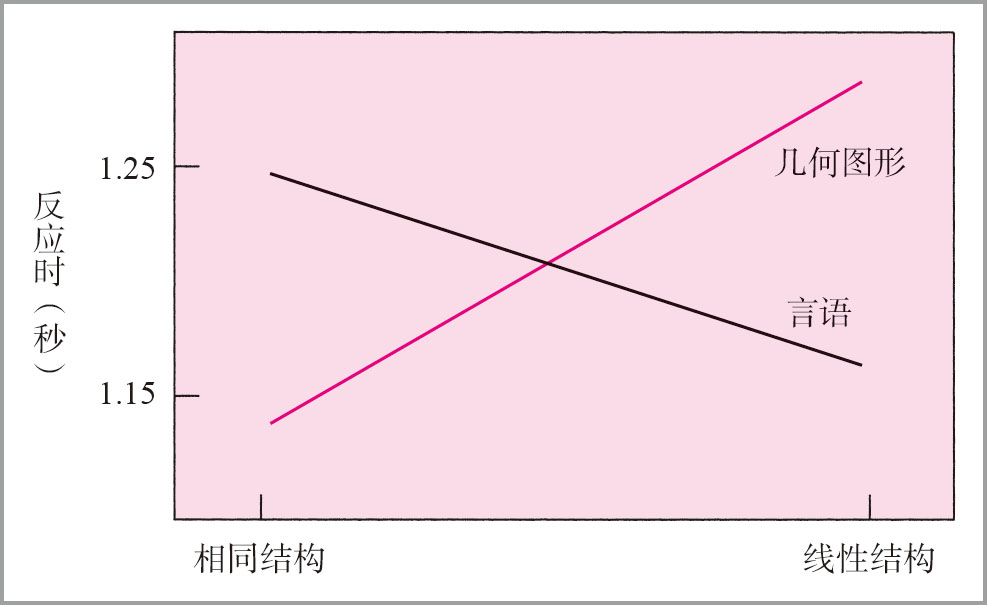

图4.3 桑塔（Santa，1977）的实验结果。数据结果证实了桑塔的两个假设：（1）在几何图形条件下，被试在图形结构相同时做出肯定回答的速度要快于线性结构，因为对学习材料的视觉表象保留了空间信息；（2）在言语条件下，被试在线性结构时做出肯定回答的速度快于相同结构，因为被试根据正常英语阅读的顺序对学习项目中的单词进行了线性编码。

◎言语表象和视觉表象涉及不同的脑区，并且以不同的方式表征和加工信息。

## 视觉表象

大多数关于心理表象的研究都涉及视觉表象，这也是本章的主要关注点。心理表象的一个功能是预期一个物体在不同的角度下呈现的样子。人们通常会在心里把物体旋转到某个角度。罗杰·谢泼德（Roger Shepard）和他的同事做了一系列关于心理旋转 （mental rotation）的实验。他们的研究开创了探索心理表象功能的先河，其影响也是非常深远的。非常有趣的是，这个研究的灵感来自于一个梦（Shepard，1968）：有一天谢泼德醒来时记起在梦中看到一个3-D结构的物体在空间中旋转。他说服了斯坦福大学一年级的研究生杰姬·梅茨勒（Jackie Metzler）和他一起研究心理旋转，于是这一切都载入了史册。

他们的第一个实验发表在《科学》（Science ）上（Shepard & Metzler，1971）。在实验过程中，给被试看在2-D平面上呈现的成对出现的3-D物体，如图4.4所示。被试的任务是判断除了摆放方向外，两个物体是否完全相同。图4.4a中的两个物体是相同的，虽然摆放的方向不同；图4.4b中的两个物体也是如此。被试报告说，为了匹配这样的两个物体，他们要在头脑中旋转其中的一个直到它们重合在一起。图4.4c中的两个物体就没有办法旋转成互相重合的状态。

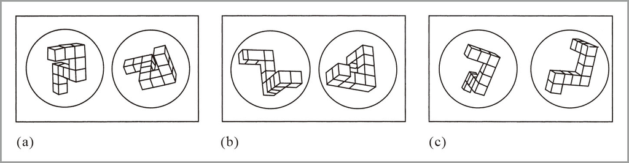

图4.4 谢泼德和梅茨勒（Shepard & Metzler，1971）的心理旋转研究中使用的刺激材料。（a）两个物体在纸平面（二维）上相差80度角。（b）两个物体在纵深方向（三维）相差80度角。（c）两个物体无法旋转成相同。 （资料来源：Metzler & Shepard，1974．Reprinted by permission of the publisher．©1974 by Erlbaum.）

图4.5所示的是被试判断两个物体是否相同所需要的时间。图中的点表示的是两个物体之间相差不同角度时所对应的反应时。相差的角度可以代表旋转一个物体的方向直到与另一个物体匹配时所需的数量。可以看到其关系是线性的——相同的旋转增量，对应相同的反应时增量。根据两种不同的旋转类型，分别绘出了反应时图。一种是在2-D旋转的情况下（图4.4a），也就是在纸平面上旋转；另一种情况是纵深方向旋转（图4.4b），此时被试需要将物体旋转到纸内。注意这两种方式的结果是非常相似的。在纵深方向上（三维）加工物体并没有表现出比在纸平面上加工物体更长的反应时。由此，被试肯定是同时在平面和纵深两种情况下操纵物体的3-D表征。

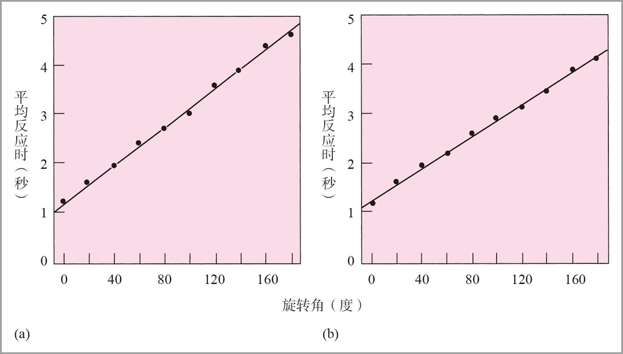

图4.5 谢泼德和梅茨勒（Shepard & Metzler，1971）心理旋转研究的结果。图中绘出了在两个物体摆放的方向相差不同的角度时，判断其3-D结构是否相同所需要的平均反应时。（a）物体需要在纸平面上（二维）旋转的结果图。（b）物体需要在纵深方向上（三维）旋转的结果图。 （资料来源：Metzler & Shepard，1974．Reprinted by permission of the publisher．©1974 by Erlbaum.）

这些数据似乎表明被试在他们的头脑中对物体进行了3-D空间内的旋转。两个物体之间相差的角度越大，被试完成旋转所需要的时间越长。虽然被试明显地没有在头脑中旋转真实的物体，但是心理加工过程却类似于物理上的旋转。

随后，出现了大量后续研究来检验各种不同物体的心理旋转。典型的发现就是完成旋转所需要的时间确实随着相差角度的不同而变化。近年来，许多脑成像研究开始探索哪些脑区参与到心理旋转的过程中。果不其然，大脑的顶叶（见图4.1中大脑后上部标示为R的区域）在一系列的任务中都得到了激活。这些发现与第3章中提到的结果相一致，即大脑的顶叶对空间注意有重要的作用。有些任务还激活了其他一些脑区。例如，科斯林等人（Kosslyn，DiGirolamo，Thompson，& Alpert，1998）发现人们在想象中旋转自己的手时，运动皮层也有所激活。

对猴子的神经元记录为进行涉及手部运动的心理旋转时的神经元表征提供了一些证据。乔哥保罗斯等人（Georgopoulos，Lurito，Petrides，Schwartz，& Massey，1989）训练猴子完成一项任务，在这项任务中猴子将手柄移动到与给出的刺激成特定角度的位置。在基线条件下，猴子只要将手柄移动到刺激的位置上。乔哥保罗斯等人发现，不同的细胞会在不同的特定位置放电。例如，当猴子移动手柄到时钟9点的位置时有些细胞的放电最强烈，当猴子移动手柄到12点钟的位置时另一些细胞放电最强烈。在旋转条件下，猴子必须将手柄移动到与给出的刺激位置成一定旋转角度的位置。例如，如果猴子必须将手柄移动到距刺激位置逆时针旋转90度的位置，且刺激出现在12点钟的位置上，它们就必须将手柄移动到9点钟的位置上。如果刺激出现在6点钟的位置上，那么它们就需要将其移动到3点钟的位置上 <sup>(3)</sup> 。角度越大，猴子们在开始行动前所需的时间越长，说明这个任务中包含了心理旋转过程以实现位置变换。在旋转条件下，乔哥保罗斯等人发现在变换的过程中，不同的细胞在不同的时间表现出兴奋。在一次变换试验开始，也就是刺激刚呈现的时候，兴奋的细胞大多与刺激移动的方向有关。在一次变换试验结束，也就是猴子真正移动手柄的时候，激活程度最大的是与运动有关的细胞。在变换的开始和结束之间，代表各个中间方向的细胞的激活最强烈。这些结果表明心理旋转包含着一系列细胞的逐次兴奋过程，开始于编码初始刺激的细胞，终止于编码变换后的刺激的细胞，在这个案例中即是编码变换后作反应的细胞。

◎当人们必须改变一个心理表象的方向以进行某种比较时，他们旋转表象的表征，经过一系列的中间位置，以达到目标方向。

### 表象扫描

通常，我们用心理表象所做的事还包括扫描心理表象以寻找关键信息。例如，当问及人们家里有几扇窗户时（本章开头所介绍的任务），许多人都报告说他们在数窗户的同时在心里扫视了家里的房子。研究者们感兴趣的是人们在这些任务中多大程度上真正扫描了知觉表征，还是仅仅提取了抽象的信息。例如，我们真的‘看见’家里的每一扇窗户，还是我们恰好记得家里有几扇窗户？

布鲁克斯（Brooks，1968）为了研究视觉表象的扫描做了一系列重要的实验。他让被试在想象中扫描图4.6中那样的图形。例如，被试扫视一个想象中的空心F，起点和方向按图所示，并判断每个拐角的顶点是在图形的最上面或最下面（作“是”反应），还是在中间（作“否”反应）。在这个例子中，正确的回答序列应该为（从开始的拐角算起）是、是、是、否、否、否、否、否、否、是。在非视觉的对照任务中，布鲁克斯提供给被试这样的句子：“手中的鸟不在灌木丛中（A bird in the hand is not in the bush）”。被试必须扫描记忆中的这个句子来逐个判断每个单词是否是名词。第二个实验变量是被试如何做出反应。被试的反应方式有三种：（1）说出是或否；（2）左手按键表示是，右手按键表示否；（3）在如图4.7的答题纸上依次指出Y（是）或N（否）。刺激材料（图形和句子）和输出方式这两个变量共组合出六种条件。

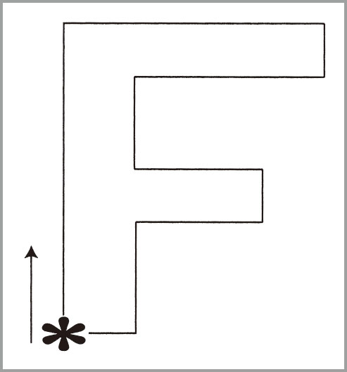

图4.6 图中简单的空心图形是布鲁克斯研究扫描心理表象时所使用的例子。星号和箭头表示被试扫描这个图形的起点和方向。 （资料来源：Brooks，1968，Reprinted by permission of the publisher．©1968 by the Canadian Psychological Association.）

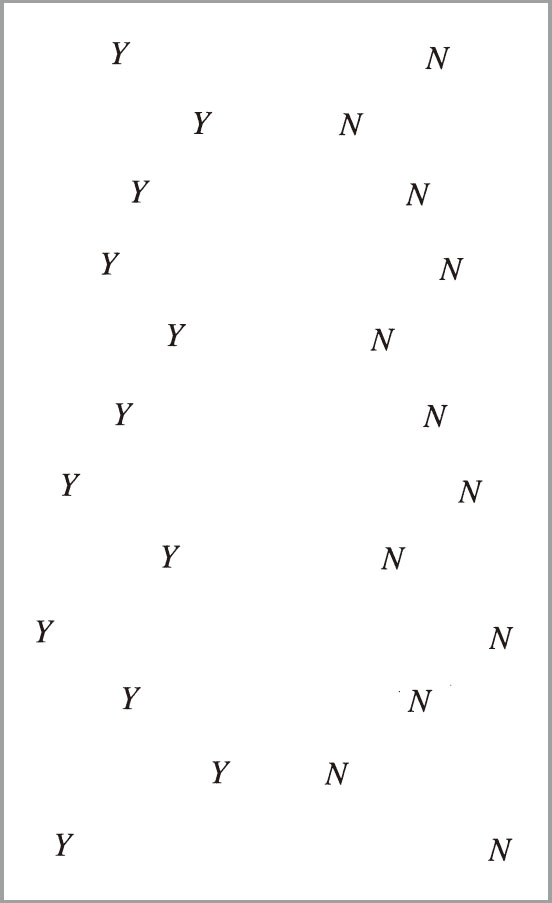

图4.7 在布鲁克斯的心理表象扫描研究中，用于指出Y或N的答题纸的例子。字母交错排列以保证被试认真用视觉监控指出答案的过程。 （资料来源：Brooks，1968，Reprinted by permission of the publisher．© 1968 by the Canadian Psychological Association.）

表4.1给出了布鲁克斯的实验结果，即每种输出条件下判断句子或图形的平均反应时。其中一个重要的结果是当执行图形任务时，被试在指出条件下所花费的时间比其他条件都长。但是当执行句子任务时却没有类似的结果。显然，扫描物理的视觉阵列与扫描心理的阵列相冲突。这一结果强烈印证了以下结论：当人们在扫描心理阵列时，他们是在扫描类似于物理视觉阵列的表征。要求人们同时对相冲突的外在物理视觉阵列进行扫描会干扰心理扫描。

表4.1 布鲁克斯（1968）的实验结果显示，对心理阵列的扫描和对视觉阵列的扫描之间存在冲突。

| 刺激材料 | 不同输出方式下的平均反应时（秒） |  |  |
| --- | --- | --- | --- |
|  | 指出 | 按键 | 口头报告 |
| 图形 | 28.2 | 14.1 | 11.3 |
| 句子 | 9.8 | 7.8 | 13.8 |

资料来源：Brooks，1968，Reprinted by permission of the publisher．©1968 by the Canadian Psychological Association．

有的人可能会认为布鲁克斯的结果是由于视觉指出任务和扫描视觉表象之间的冲突引起的。然而，后续的实验清楚表明，干扰的产生在本质上并不是因为任务的视觉特征。主要问题是空间的，而不是特定的视觉因素；也就是说被试必须扫描的物理阵列的方向和心理表象的方向是冲突的。例如，在另一个实验中，布鲁克斯发现，当被试闭上眼睛并且通过用手指触摸一系列突起的Y和N来作出是或否反应时，也得到了相似的结果。在这种情况下，真实的刺激是触觉的，而不是视觉的。因此，冲突是空间的，不是特定视觉的。

巴德利和利伯曼（Baddeley & Lieber-man，1976）做的一个实验强烈支持了布鲁克斯任务中的干扰本质上是空间的不是视觉的这个观点。实验要求被试要同时完成两项任务。所有的被试都要完成布鲁克斯的字母-表象任务 <sup>(4)</sup> 。另外，一组被试要看着一系列刺激，这些刺激有两种亮度，只要较亮的刺激出现时就按键反应。这个任务需要视觉加工但是不需要空间加工。另一组被试蒙住双眼坐在一个摆动的钟摆前面。钟摆会发出声音并且里面装有光电管。被试要试着让手电筒的光柱始终照在摆动的钟摆上。当照在上面的时候，在光电管的作用下声音的频率就会改变，因此被试获得了听觉反馈。这个任务涉及到空间信息的加工而不是视觉信息。比起亮度判断任务，空间听觉追踪任务对表象扫描任务造成的干扰大得多。这一结果也证明布鲁克斯任务中干扰的本质是空间的，不是视觉的。

◎如果人们在进行心理表象扫描的同时还必须加工冲突性的知觉结构信息，那么两个任务就会相互干扰。

### 大小的视觉比较

相当数量的研究聚焦于人们如何在心理表象中判断物体视觉上的细节特征。一种研究思路是让被试基于某种维度，例如大小，来判断两个物体之间的差别。这种研究发现当被试试图区别两个物体时，两个物体的大小差异越大，他们做出判断所花费的时间越短。

莫耶（Moyer，1973）感兴趣于被试判断记忆中两种动物的相对大小的速度。例如，“鹿和蟑螂哪个大？”或者“狼和狮子哪个大？”许多人报告说在做判断的时候，特别是当两个物体大小相似的时候，他们都会在头脑中出现两个物体的表象，并且似乎在通过表象比较大小。

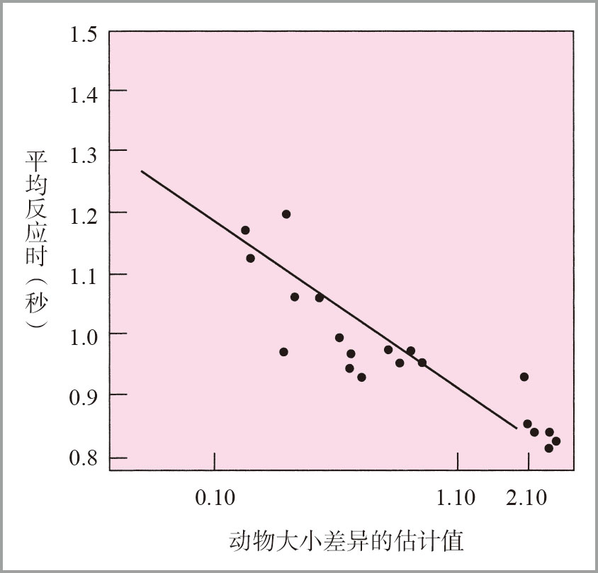

图4.8 莫耶的实验结果表明当人们要区别两个物体时，他们所需要的时间随着两个物体之间差异的增大而减少。被试要比较两种想象中的动物的大小，判断两种动物哪个更大所需要的平均反应时随对两种动物大小差异的估计而变化。对差异的测量在横坐标上用对数表示。 （资料来源：Moyers，1973，Reprinted by permission of the publisher．©1973 by Perception and Psychophysics ）

莫耶还让被试估计这些动物的绝对大小。他绘制了散点图，比较表象中两种动物大小所需要的时间与两种动物大小差异的估计值之间的函数关系。图4.8再现了这些数据。图中的这些散点反映了一对对项目之间的比较。总的来说，判断的时间随差异估计值增大而减少。从图中可以看出，随着动物大小差异的增大，判断时间线性地减少。但是，要注意，差异是以对数表示的。对数-差异尺度使小差异之间的数值差在坐标上显示的距离相对地大于大差异之间的同等数值差在坐标上显示的距离。因此，图中的线性关系表示随着大小差异的增加，它对反应时的影响相对减少。

重要的是，当人们在视觉上比较物理大小时也得到了非常相似的结果。例如，约翰逊（D．M．Johnson，1939）让被试判断同时出现的两条线段哪条更长。图4.9所示的是被试判断的时间与线段长度差异的对数之间的函数关系。可以看到，又出现了线性的关系。我们有理由预期被比较的量越相似，进行知觉上的判断所需要的时间越长，因为在这种情况下，精确地分辨它们更为困难。在比较物体的心理表象时获得了与此相似的函数。这一事实表明，进行心理比较与进行知觉比较涉及相同的加工过程。

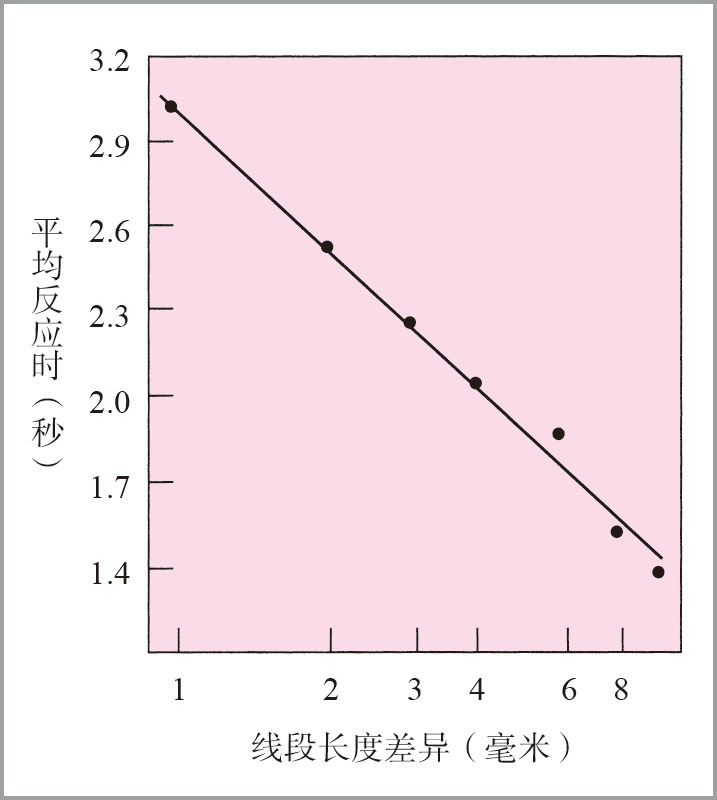

图4.9 约翰逊（D．M．Johnson，1939）的研究结果表明，进行心理比较的难度与进行知觉比较是相似的。被试比较两条线段的长度。图中被试判断哪条线段较长的平均反应时是线段长度差异的函数。差异的测量在横坐标上以对数表示。

◎人们在判断大小相似的两个图形或两个心理表象的相对大小时，会遇到较大困难。

### 视觉表象类似于视知觉吗

已经有研究考察了视觉表象与知觉的相似程度到底有多大。在一项实验中，芬克等人（Finke，Pinker & Farah，1989）研究了人们是否能像识别见到的物体那样识别他们所建构的表象。研究者们让被试建立心理表象，然后对这些表象进行一系列的改变。下面是两个读给被试听的问题的例子：

- 想象一个大写字母N。从右上角到左下角画一条对角线。现在将图形向右旋转90度，你看到了什么？
- 想象一个大写字母D，将其向左旋转90度。现在在下面放一个大写字母J，你看到了什么？

被试闭上眼睛并且试着按照听到的指导语进行想象。被试能够辨认自己合成的表象，就像它们呈现在屏幕上似的。在第一个例子中，他们看到了一个沙漏（hourglass） <sup>(5)</sup> ；在第二个例子中，他们看到了一把伞。完成这些任务的能力说明了表象的重要功能：它能让我们在头脑中建构新的事物并且审视它们。这种视觉合成就是结构工程师或建筑师在设计新的桥梁或楼房时必须做的事情。

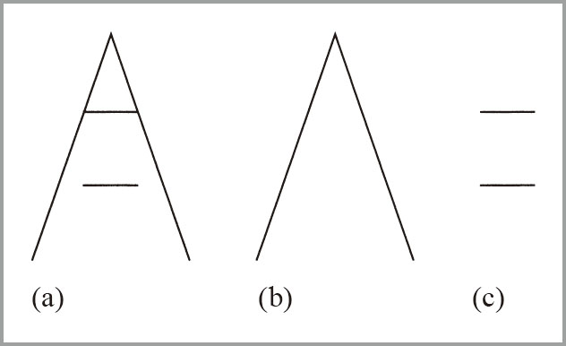

图4.10 庞佐错觉示例（a）：即使两条水平线长度相同，但是上面那条看起来较长一些。（b）和（c）是华莱士（Wallace，1984）用来研究表象中的错觉的材料示例。被试想象把它们结合在一起使（b）中的两条斜线正好接触到（c）中的水平线。 （资料来源：Wallace，1984．Reprinted by permission of the publisher．© by the Psychonomic Society.）

钱伯斯和雷斯伯格（Chambers & Reisberg，1985）报告了一项实验研究，这项研究似乎说明了心理表象和真实物体的视知觉之间存在差异。他们的研究涉及可逆图形的加工，例如图4.11中的鸭-兔。给被试简短展现图形，然后让他们形成图形的表象。在图形消失前，被试只有足够的时间对图形做出一种解释，但是要求被试努力进行第二种解释，被试无法完成这样的任务。随后让被试在纸上画出图形，看他们是否能够重新解释，这时被试就能够完成任务。这一结果表明视觉表象不同于图像，人们只能用一种方式解释表象，而无法进行其他的解释。

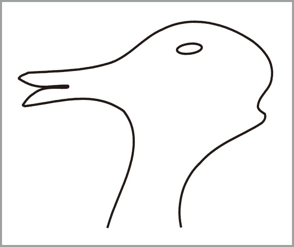

图4.11 钱伯斯和雷斯伯格研究可逆图形加工时使用的鸭-兔歧义图。 （资料来源：Chambers & Reisberg，1985．Reprinted by permission of the publisher．©1985 by the American Psychological Association）

随后，彼得森等人（Peterson，Kihlstrom，Rose，& Gilsky，1992）发现，通过更为明确的指导语能够让被试逆转心理表象。例如，告诉被试如何逆转另一个图形或者思考把表象中动物头的后面当作另一种动物头的前面。因此，虽然逆转表象比逆转图片要困难，但是两者都是可以逆转的。总之，加工表象似乎比加工真实刺激的难度大。假如可以选择，人们都会选择加工真实的图片而不是去想象它。例如，玩俄罗斯方块的人都倾向于在屏幕上旋转图形来找到适当的方位，而不是在心里旋转它们（Kirsh & Maglio，1994）。

◎通过心理表象做出与真的看见某物相同的细节判断是可能的，尽管这较难做到。

### 视觉表象与脑区

脑成像研究显示心理表象与知觉加工涉及相同的脑区。正如我们已经看到的，与对位置和目标的注意有关的顶叶区域（见上一章）也参与心理旋转的加工。

欧克拉文和坎威斯尔（O'Craven & Kanwisher，2000）的研究说明了表象激活的脑区和知觉激活的脑区的相接近程度。在第2章中曾讲到颞叶皮层的梭状回优先对脸部作反应。颞叶的另一个区域，海马旁回位置区 （the parahippocampal place area，PPA），优先对位置图片作反应。欧克拉文和坎威斯尔让被试观看或者想象脸部和场景。被试在看的时候和在想象的时候激活了相同的区域。图4.12比较了梭状回脸部区 （fusiform face area，FFA）和PPA的激活情况。每次被试在看或者在想象脸部时，FFA的激活程度都有所增加，而在加工场景时激活又减弱。相反地，当他们看或想象场景时，PPA的激活增加，在加工脸部时激活又减弱。想象时的反应与知觉时的反应非常相似，只是程度稍弱。想象时反应稍弱与我们讨论过的加工表象比真实的知觉要困难的行为证据相一致。

有许多类似的研究都表明了表象加工涉及到较高层次的视觉加工所激活的脑皮层区。但是关于视觉信息首先到达的初级视觉皮层（17区和18区）的激活证据还不够明朗。欧克拉文和坎威斯尔的研究发现，初级视觉皮层在表象加工中会有所激活。这一结果非常重要，因为它表明视觉表象包含了相对低层次的知觉加工过程。但是，并不总是能在初级视觉皮层发现这样的激活。例如，图4.1所示的罗兰和弗雷伯格的研究就没有发现这一区域的激活（又见Roland，Eriksson，Stone-Elander，& Widen，1987）。科斯林和汤姆森（Kosslyn & Thompson，2003）综述了59项脑成像研究来探寻早期视觉区的激活情况。这些研究中大约有一半发现了早期视觉区的激活，而另一半没有发现。他们的分析表明，发现早期视觉区激活的研究倾向于强调图像的高清晰细节并注重形状的判断。以一项有激活的研究为例，科斯林等人（Kosslyn et al.，1993）发现，被试在想象印刷体字母时17区有激活。在他们的一个实验中，要求被试想象大小不同的字母。在小字母条件下，视觉皮层中激活的区域更靠近后部，接近表征视野中心的部位（视野是拓扑组织的，见图2.6 ）。这个结果是有道理的，因为小的表象可能主要集中在视野的中心。

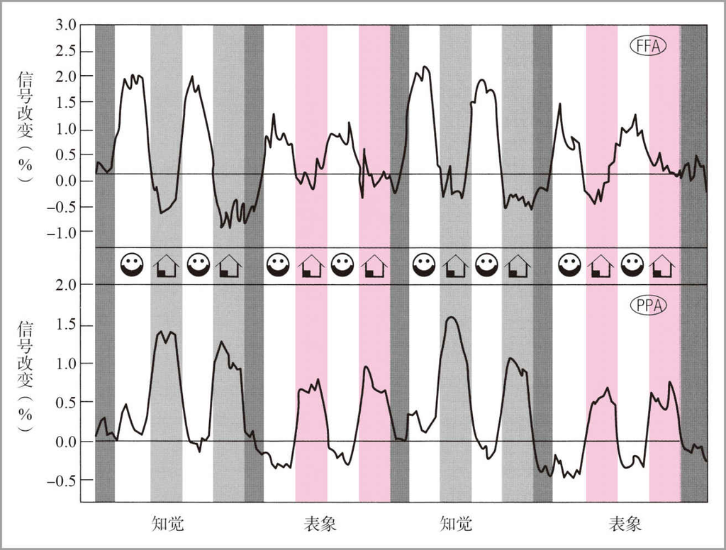

图4.12 欧克拉文和坎威斯尔的研究结果表明，加工视觉表象的方式与真实的知觉相同，也涉及许多相同的神经结构。当被试知觉（或想象）脸部和地点时，分别激活了大脑的梭状回脸部区（FFA，上图）和海马旁区（PPA，下图）。 （资料来源：O'Craven & Kanwisher，2000．Reprinted by permission of the publisher．© 2000 by the Journal of Cognitive Neuroscience .）

虽然这些成像研究显示，当被试进行心理表象加工时大脑的知觉区得到了激活，但是它们无法认定这些区域对心理表象是否真的至关重要。回到本章开头关于副现象的说法，这种激活可能对执行真正的任务并没有影响。目前，许多实验利用经颅磁刺激（TMS，见图1.13 ）来考察这些区域与完成基本任务间的因果关系。例如，科斯林等人（Kosslyn et al.，1999）给被试呈现如图4.13中的四个象限的阵列，并要求他们建立阵列的心理表象。然后，阵列消失后，被试必须利用他们的表象来回答这样的问题：“哪个象限中的条纹较长，第一象限还是第二象限？”“哪个象限中的条纹较多，第一象限还是第四象限？”对初级视觉17区施加TMS显著延长了他们回答这些问题的时间。因此，这些视觉区域似乎对心理表象起到了“因”的作用，并且暂时抑制它们会使信息加工受损。

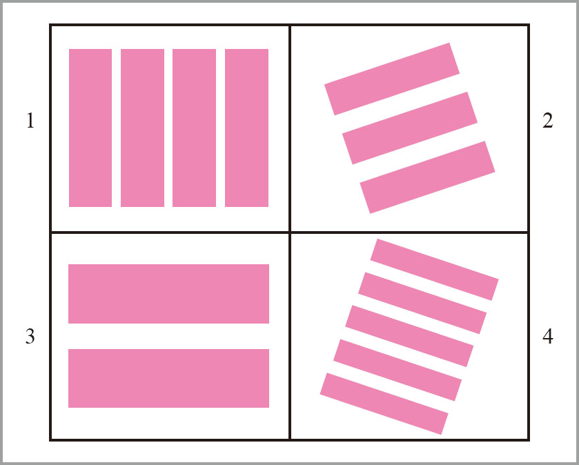

图4.13 科斯林等人（Kosslyn et al.，1999）所使用刺激材料的示意图。数字1、2、3、4标示着四个象限，每个象限中都有一组条纹。在记住图像后，被试闭上眼睛，想象整个图像，然后听到两个象限的名称，并听到需要比较的内容（例如，‘长度’）；接着，被试判断第一个被说出的象限中的条纹是否比第二个被说出的象限中的条纹具有更强的所需要比较的属性。

◎当执行视觉表象任务时，参与视知觉的脑区有所激活，并且干扰这些区域会干扰表象任务的执行。

### 表象既包括空间成分又包括视觉成分

我们已经了解到，布鲁克斯（Brooks，1968）的研究表明人们对心理表象的空间结构敏感，而莫耶（Moyer，1973）的研究表明人们可以在心理表象中加工视觉细节特征，例如大小。最近的研究发现心理表象的空间和视觉属性之间的差别是非常重要的。我们可以通过看到物体在哪、感觉它们在哪或听到它们在哪来编码物体的空间位置。这样的编码利用了整合来自任意感觉通道的信息的共同空间表征。另一方面，视觉经验的某些方面，如颜色，只能通过视觉通道来获得，似乎独立于空间信息。因此，表象既包括空间成分也包括视觉成分。在第二章对视觉系统的讨论中，我们了解到“哪里”通路加工空间信息，“什么”通路加工物体信息（见图2.1 ）。与这种区分相对应，有证据表明大脑的顶叶支持视觉表象的空间成分，而颞叶支持视觉成分（见图4.1）。我们已经注意到心理旋转（一种空间任务）更多地激活顶叶皮层。相对地，当人们在想象物体的特征时颞叶得到激活（Thompson & Kosslyn，2000）。

关于表象的病人研究也支持了空间表象与顶叶有关，而视觉表象与颞叶有关。莱文、沃尔奇和法拉（Levine，Warach，& Farah，1985）比较了两个病人，一个是双侧顶枕区损伤，而另一个是双侧颞下损伤。顶叶损伤的病人无法根据记忆描述出熟悉的物体或地标的位置，但是他能够描述物体的外形。颞叶损伤的病人描述物体外形的能力受损，但是却能讲出它们的位置。

◎神经心理学的证据表明空间信息的表象与大脑的顶叶结构有关，而物体的表象和它们的视觉属性与颞叶结构有关。

### 认知地图

视觉表象的另一个重要功能是帮助我们认出和记住环境的空间结构。我们对世界的表象表征通常被称为认知地图 （cognitive maps）。在认知地图中可以明显展现出表象与行动之间的联系。在计划如何从一个地方去另一个地方时，我们会经常发现自己在想象周围的环境。

一种重要的分类是行进图 （route maps）和俯瞰图 （survey maps）（Hart & Moore，1973）。行进图指明到达具体地点的通路，但是不包含2-D信息。行进图甚至可以是用语言描述出来的通路（“直走，到红绿灯左转，过两个街区的十字路口……”）。因此，只知道行进图的话，如果从位置1到位置2的路被堵住了，你可能并不知道位置2到底在哪里，也不知道该怎么绕路走。或者，如果你知道从同一源头出发的两条路（行进图），你可能也并不知道这两条路之间成90°角还是120°角。相反地，俯瞰图中包含这样的信息。它就好像是周围环境的空间表象。当你通过典型的网上地图查询路线时，为了支持空间的两种心理表征，他们既会提供行进图也会提供俯瞰图。

索恩代克和海斯-罗思（Thorndyke & Hayes-Roth，1982）研究了秘书们对美国兰德公司大楼（图4.14）的了解，兰德公司大楼是美国加利福尼亚州圣莫尼卡市一幢迷宫一样的大楼。他们发现秘书们很快就能记住从大楼的一个指定地点到另一个地点的路。例如，从库房到出纳台。这就是行进图。但是，秘书们一般需要在大楼里熟悉若干年才能获得俯瞰图并依此进行判断。譬如说，从复印室到餐厅的方向。

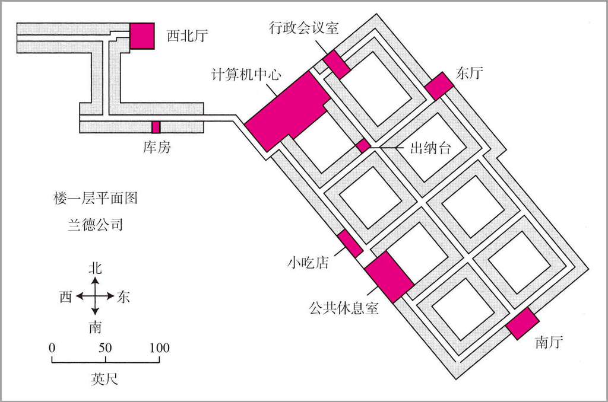

图4.14 美国加利福尼亚州圣莫尼卡市兰德公司大楼楼层的部分平面图。索恩代克和海斯-罗思研究了秘书们熟悉大楼通路的能力。 （资料来源：Thorndyke & Hayes-Roth，1982．Reprinted by permission of the publisher．© 1982 by Cognitive psychology .）

哈特利等人（Hartley，Maguire，Spiers，& Burgess，2003）考察了当人们使用这两种表征时不同脑区的激活情况。他们让被试在虚拟现实的城镇里寻路，一共有两个条件。在跟随路径（route-following，R）的条件下，被试学习沿着固定的路径穿越城镇。在寻找路径（way-finding，W）条件下，被试先自由探索城镇，然后必须找出两个地点之间的路径。研究者比较了被试完成跟随路径和寻找路径任务时的fMRI激活情况。实验结果见彩色插页4.1 。在寻找路径任务中，被试的许多在其他视觉表象研究中也有所发现的脑区都表现出了更强的激活，包括顶叶皮层。他们还发现了海马（见图1.7 ）的更强激活，这一区域已经被发现在许多物种中都发挥着导航的作用。相反，在跟随路径任务中，被试在比较靠前的脑区包括 <sup>(6)</sup> 运动区表现出了更强的激活。看起来，俯瞰图更像是视觉表象，而行进图更像是行动计划。这种区别也得到了其他针对行进图和俯瞰图的fMRI研究的支持（例如，Shelton & Gabrieli，2000）。

◎我们对环境的知识既能够用强调空间信息的俯瞰图来表征，也可以用强调行动信息的行进图来表征。

### 空间的自我中心和他我中心表征

当我们需要把多种不同的空间表征结合在一起时，寻路的难度也随之增大。特别是，我们经常需要把我们知觉到的空间中的路与空间的其他表征，例如认知地图，关联起来。“就像我们看到的空间”的表征被称为自我中心表征 （egocentric representation）。图4.15表示的是一个人的自我中心表征，这个人正想要进入坐落在明尼苏达州布卢明顿市的美国广场里的史努比主题乐园。即使很小的孩子也可以很容易地在他们所看到的空间中寻路。如果他们看到想要的目标，就直接跑过去。当一个人要把所看到的与认知地图这样的空间表征联系起来时，不论是行进图还是俯瞰图，问题就产生了。当一个人面对物理地图时，例如图4.16中的史努比主题乐园地图，也会产生类似的问题。这种地图被称为他我中心表征 （allocentric representation），因为它并没有一个固定的观察位置，虽然大多数地图都遵循上北下南的规则。假设你站在图4.16里小人所在的位置，试着找出图4.15中标着圆圈的建筑物在地图上的位置。当人们想要做这种判断时，从他们的实际观察方向到地图里小人的观察方向所需旋转的角度有很大影响。实际上，人们经常要旋转物理地图从而找到对应的方位。图4.16中的地图逆时针旋转约90°就可以到达图4.15中表征的方位。

[figure not shown]

图4.15 美国广场史努比主题乐园的自我中心表征。 （资料来源：Courtesy of Camp Snoopy/Bob Cole.）

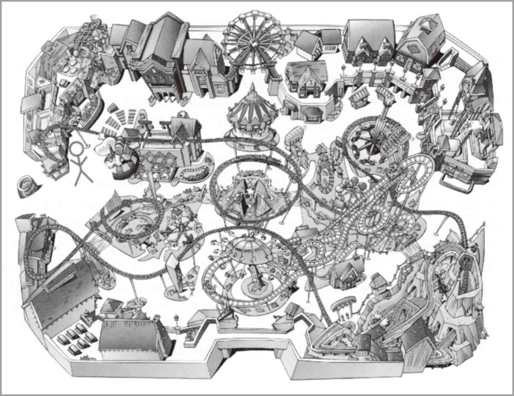

图4.16 史努比主题乐园的他我中心表征。 （资料来源：Courtesy of Camp Snoopy/Bob Cole.）

当无法在物理上旋转地图时，人们会表现出这两个方位间角度差异的效应，这个效应与心理旋转中所看到的效应非常相似（例如，Boer，1991；Easton & Sholl，1995；Gugerty，deBoom，Jenkins，& Morley，2000；Hintzman，O'Dell，& Arndt，1981）。图4.17所示的是纲泽尔曼和安德森（Gunzelmann & Anderson，2002）最近一项研究的结果，他们考察了在一幅标准地图（即上北下南的地图）上找到目标所需要的时间与观察者位置之间的函数关系。观察者坐南朝北比坐北朝南（与地图方向相反）时更容易找到目标。有的人会说他们想象自己在地图上移动，有的人则说他们旋转看到的事物，还有人会使用言语表述（“史努比处左转，大转轮的前面”）。在这个任务中角度差异的影响与心理旋转中类似，这一事实使得很多研究者相信，这种寻路任务中的加工和表征类似于心理表象中的加工与表征。

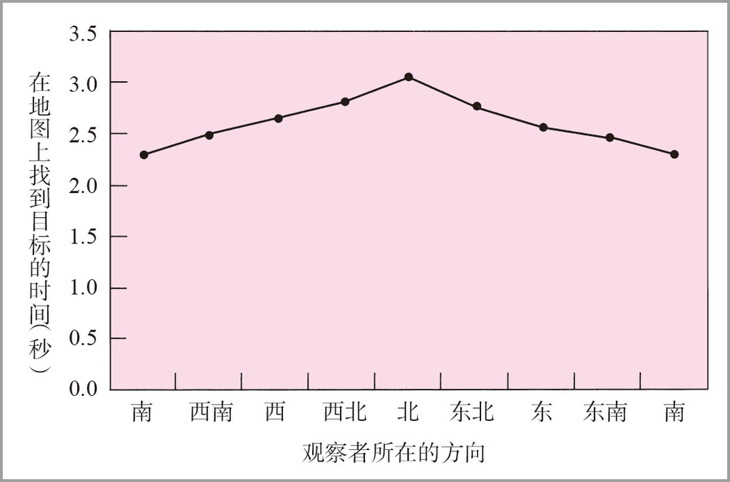

图4.17 纲泽尔曼和安德森的研究结果表明了标准地图（上北下南）与观察者朝向之间的角度差异对人们在地图上寻找目标的能力的影响。被试寻找目标所需要的时间与地图和自我中心视角的方向差异之间的函数如图所示。 （资料来源：Gunzeimann & Anderson，2002.Adapted by permission of the publisher．© 2002 by Erlbaum.）

物理地图与认知地图似乎有一个重要的不同：物理地图具有方向效应，而认知地图没有。例如，想象自己站在卧室的各面墙前面并指出你家或公寓的大门位置。不论所处的位置如何，大多数人都能够同样好地完成任务。相对地，如果给出像图4.16中的地图，人们会发现，如果他们的方向和地图一致，则更容易指出各种目标。

对大鼠的海马区（在颞叶内部）进行单细胞记录表明海马对维持世界的他我中心表征有非常重要的作用。海马中有位置细胞，当动物在它们所处环境中的某一特定位置时，对应的位置细胞的兴奋水平最高（O'Keefe & Dostrovsky，1971）。在人类病人进行癫痫手术前，对大脑进行定位程序时也记录到了类似的细胞（Ekstrom et al.，2003）。脑成像研究显示，当人类在环境中寻路时，海马有高度激活（Maguire et al.，1998）。另一项研究（Maguire et al.，2000）显示伦敦出租车司机的海马体积大于不开出租车的人，并且体积随着当出租车司机的时间增长而增大。要想胜任一名出租车司机必须要3年的辛苦训练来完全熟悉伦敦的道路，这些训练似乎对大脑结构也产生了影响。海马结构的激活水平也与寻路技能的年龄差异相关（Pine et al.，2002），并且可能与寻路能力的性别差异相关（Gron，Wunderlich，Spitzer，Tomczak，& Riepe，2000）。这些相关的区域中包含PPA，即欧克拉文和坎威斯尔（O'Craven & Kanwisher，2000）所发现的在被试想象地点时所激活的区域（见图4.12）。

虽然海马看起来对他我中心表征来说非常重要，但是顶叶皮层似乎对自我中心表征也起到了特别重要的作用（Burgess，2006）。一项fMRI研究（Zaehle et al.，2007）比较了自我中心和他我中心空间加工过程，其中被试要根据他我中心观点或自我中心观点进行决策。在他我中心条件下，被试会读到这样一段描述：“蓝色三角在绿色方块的左侧，绿色方块在黄色三角的上方，黄色三角在红色圆圈的右侧。”然后，他们要回答这样的一个问题：“蓝色三角在红色圆圈的上方吗？”在自我中心条件下，他们会读到这样一段描述：“蓝色圆圈在你的前方，黄色圆圈在你的右侧，黄色方块在黄色圆圈的右侧。”然后他们要回答问题：“黄色方块在你的右侧吗？”海马的激活在被试回答他我中心条件的问题时，比回答自我中心条件的问题时强。虽然在两种条件下顶叶皮层都显示出相当大的激活，但是自我中心条件下的顶叶激活明显要强得多。

◎我们的空间表征包括他我中心表征和自我中心表征，在前者中物体位于外界环境中，在后者中物体与我们自身方位相关。

### 地图曲解

我们的心理地图通常具有多层次的结构，较小区域包含在较大区域之中。例如，我的卧室在我的房屋结构之中，而房屋又在邻里社区结构之中，邻里社区又处在匹兹堡的大结构之中。思考一下你对于美国的心理地图。它可以分为很多地区，这些地区可以分成不同的州，州里又散布着城市。所以这些心理地图的多层次结构就产生了某些系统性的曲解。史蒂文斯和库普（Stevens & Coupe，1978）给出了一系列关于北美地理的普遍错误观念。请看下列他们的研究中提到的问题：

- 哪个城市更靠东：圣地亚哥还是里诺 <sup>(7)</sup> ？
- 哪个城市更靠北：西雅图还是蒙特利尔 <sup>(8)</sup> ？
- 哪个地方更靠西：巴拿马运河的大西洋入口还是太平洋入口？

每道题的正确答案都是第一个选项，但是大多数人都答错了。里诺似乎更靠东，因为内华达州在加利福尼亚州东边，但这样的推理没有考虑到加利福尼亚海岸线向西的弧线。蒙特利尔似乎在西雅图的北边，因为加拿大在美国的北边，但美加东部的边境线是向南倾斜的。（对于北美）大西洋确实在太平洋的东边——但是对于巴拿马运河，你可以在地图上看看到底如何。北美的地理情况十分复杂，人们常常借助一些抽象的事实进行判断，例如用大的物理地区（如加利福尼亚州和内华达州）来判断小的地区（如圣地亚哥和里诺）。

史蒂文斯和库普能够用实验者自创的地图来说明这些混淆。不同组的被试学习图4.18中的地图。不一致地图的重要特征是阿尔法郡和贝塔郡的相对位置与X和Y城市的位置不一致。在学习了地图之后，被试需要回答一系列和城市位置有关的问题，例如对于左侧的地图，问被试“X在Y的东面还是西面？”然后对于右侧的地图，问被试“X在Y的南面还是北面？”。在这些问题上，被试在一致地图上的错误率是18％，在无边界地图上的错误率是15％，但是在不一致地图上的错误率却是45％。被试使用了郡的位置信息来帮助他们记住城市的位置。如此依赖于更高层次的信息使他们犯错误，类似于导致回答北美地理问题出错时的推理过程。

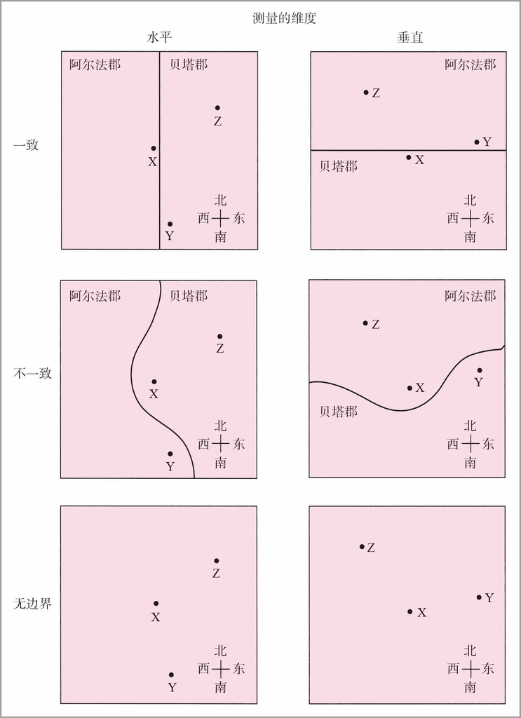

图4.18 在史蒂文斯和库普的实验中被试所要学习的地图，说明了高层次信息（郡界线的位置）对被试回忆城市位置的影响。 （资料来源：Stevens & Coupe，1987．Reprinted by permission of the publisher．© 1978 by Cognitive Psychology .）

◎当人们必须判断两个地点的相对位置时，他们通常根据这两个地点所属大区域的相对位置来进行推断。

### 将文字转换成表象

空间认知的另一个重要功能是当我们听到对一个空间结构的文字描述时可以创造心理表象。例如，当我们确定方位、阅读对一个事件的描述或者听体育赛事转播时，上述情况就会发生。英国心理学家艾伦·巴德利（Alan Baddeley）报告说，当他想要听广播中的美国橄榄球比赛时就无法好好开车，因为产生了冲突的表象。为了对由言语建构空间表象可能遇到的困难程度有所了解，请看表4.2中的阅读材料。

表4.2 富兰克林和特韦尔斯基（Franklin & Tversky，1990）的实验中被试阅读的材料

你来到歌剧院，今晚你要与上流社会的名人会面。这时，你站在宽敞雅致的包厢围栏前望着楼下。在你身后的包厢墙上齐眉高处有一盏装饰华丽的灯，灯的基座镀着炫目的金色。在你的正前方，包厢外的墙上，可以看到一块巨大的青铜匾额，用来纪念剧院的设计者。建筑师的简单肖像和对他的几句描述在青铜的背景中略微凸起。在你右侧的搁板上放着一束美丽的鲜花，你看到花束中大多是红色的玫瑰和白色的康乃馨。向上看，在你上方约20英尺处的剧院天花板上装着一个扩音器。从它的方向，你断定这是专门为这个包厢里的客人服务的私人扬声器。靠在包厢的围栏上往下看，在你的正下方矗立着一尊大理石雕像。你仔细凝望着雕像，发现它雕刻的是一个年轻的男人，于是你想知道这是否是米开朗基罗的《大卫》的一个复制品。

资料来源：Franklin & Tversky（1990）．Reprinted by permission of the publisher.© 1990 by Journal of Experimental Psychology：General ．

富兰克林和特韦尔斯基（1990）让被试阅读这样的故事。随后，让被试基于这些叙述重新调整自己的方位，例如：

你仍然站在包厢的原位，将身体向右旋转90°，现在你面对着灯。你看到墙上安装着短小坚固的圆柱，也许这是预防地震的。

然后，他们要判断在某个特定的方位上有什么东西。例如，在不同的测试中，他们要回答什么在他们的右边、左边、上边、下边、后边或前边。

图4.19所示的是被试在判断不同的方位时所需要的时间。被试判断上下的速度是最快的，而判断左右的速度是最慢的。富兰克林和特韦尔斯基指出，如果我们假设被试在阅读文字时建构了空间表征，那么这样的结果是有道理的。当我们在真实世界中寻路时既涉及上下的垂直方向，也涉及前后的水平方向。相反地，由于身体双侧的对称性，我们经常会产生左右混淆。对于表象中的左右，我们也产生了类似的混淆。

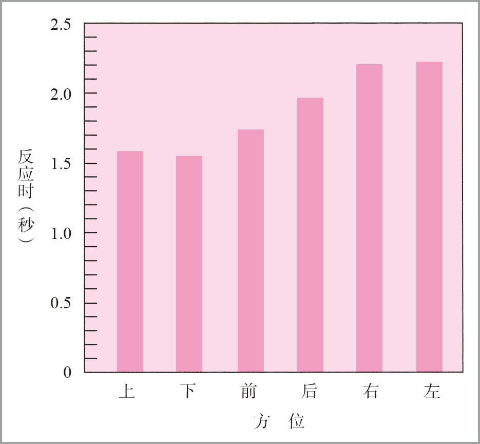

图4.19 富兰克林和特韦尔斯基的实验结果表明，我们可以根据对空间结构的文字描述建立心理表象。被试阅读一段段故事，并将自己置于想象的环境中，然后确认环境中物体的位置。图中展示的结果是确认不同方向物体所需要的时间。 （资料来源：Franklin & Tversky（1990）．Reprinted by permission of the publisher.© 1990 by Journal of Experimental Psychology：General .）

在另一项实验中，泰勒和特韦尔斯基（H.A.Taylor & Tversky，1992）比较了三种空间信息的相对有效性：行进描述、俯瞰描述和真实地图。行进描述是一种对环境的心理旅行，而俯瞰描述是一种对环境的鸟瞰。在学习了两种描述或者真实地图之后，被试要判断关于环境的行进或俯瞰陈述。行进陈述的例子如下：

驾车从市政厅到加油站，在你的右手边会经过枫树街。

俯瞰陈述的例子如下：

马蹄铁车道沿着白鸽湖北岸延伸。

被试需要判断这些句子是否符合学习过的环境信息。无论是行进描述、俯瞰描述还是真实地图，他们在判断这些问题时的速度都一样快。从这一结果中，泰勒和特韦尔斯基得出结论，人们可以像看到真实地图一样有效地从言语描述中建构认知地图。

◎我们可以将对环境的言语描述转换成认知地图。

## 结论：视觉知觉与视觉表象

本章综述了一些关于参与视觉知觉的脑区也参与视觉表象的证据。这些研究大概可以平息了本章开头提到的视觉表象只是一种副现象的说法。不过，虽然看起来视觉表象涉及知觉过程，但是视觉表象的机制与视觉知觉的机制到底有多么相似还是一个有待回答的问题。这两者有相当大的重叠的证据来自对病人的神经心理学研究（综述见Bartolomeo，2002）。许多大脑皮层受损导致失明的病人也表现出了视觉表象上的缺陷。如波曼（Behrmann，2000）提出，知觉和表象之间有着令人惊奇的对应。例如，有的病人只是不能对人脸和颜色进行知觉或表象，但是对其他事物的知觉或表象却并未受影响。尽管如此，还是有一些病人知觉存在问题但仍保留有完好的视觉表象的案例。同时，相反的病例也存在。波曼认为，最好把视觉知觉和视觉表象理解为两个相互重叠但又相互独立的过程，如图4.20所示。感知一只袋鼠需要低层次的视觉信息加工过程，但这个过程是视觉表象所不需要的。相似地，建立袋鼠的心理表象需要的产生过程也是知觉所不需要的。波曼提出，只丧失知觉功能的病人损伤的是该系统的低层次部分，而只丧失表象功能的病人损伤的是该系统的高层次部分。

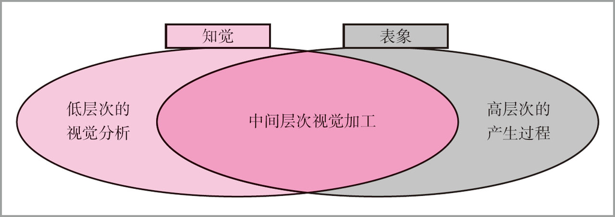

图4.20 视觉知觉和视觉表象相重叠加工的示意图。

### 思考题

1. 有假设说，我们的知觉系统在识别非标准方位的物体时通常会进行心理旋转。在第2章中，我们比较了物体识别的模板匹配和特征分析模型。心理旋转对于模板匹配模型更为重要还是对于特征分析模型更为重要？
2. 思考下面的问题：  
   想象在你视线正前方的桌面上有一个立方体。想象连接着前方左下角顶点和后方右上角顶点的最长的对角线。现在，想象这个立方体转动到与这条对角线垂直的位置，并以其前方左下角的顶点立在桌面上。把你的一根手指放在离桌面1英尺高的地方来表示原来对角线连着的上面顶点的高度。接触桌面的顶点垂直位于你的手指下方。用你的另一只手指出这个立方体其他各个顶点的空间位置。欣顿（Hinton，1979）报告说几乎没有人能成功完成这个任务。既然我们在本章列举了那么多成功的心理表象，为什么这个任务如此之难？
3. 本章综述了在执行心理表象任务中不同脑区被激活的证据：顶叶和运动区之于心理旋转、颞叶之于物体特征判断、海马之于寻路推理。为什么心理表象涉及这么多脑区？
4. 思考地图曲解，例如认为圣地亚哥在雷诺西面的倾向。这种曲解是自我中心表征、他我中心表征还是其他什么表征？

### 关键术语

心理表象

心理旋转

海马旁回位置区

副现象

梭状回脸部区

认知地图

行进图

俯瞰图

自我中心表征

他我中心表征

(1) 美国公立中小学每天都组织学生向国旗致敬并背诵《效忠誓词》。《效忠誓词》（Pledge of Allegiance）全文为：I pledge allegiance to theflag of the United States of America，and to the republic for which it stands，one nation under God，indivisible，with liberty and justice for all.——译者注

(2) 原著者在给译者的email中给出了word jingle的一个例子：‘Double your pleasure，double your fun with double mint gum’。——译者注

(3) 按Georgopoulos，et al.，1989，移动的起始点均为圆心，目标点在半径为2厘米的圆上的不同位置处。——译者注

(4) 即如图4.6所示任务。——译者注

(5) 传统的沙漏通常由两个对顶的圆锥形玻璃容器组成。——译者注

(6) 原文无‘包括（including）’，作者在email中建议增加。——译者注

(7) 美国加利福尼亚州南北长、东西相对较短，由南向北，海岸线逐步向西。圣地亚哥在南部加利福尼亚州，内华达州的里诺接近北部加利福尼亚州的东边边界。

(8) 西雅图在美国西北部，蒙特利尔在加拿大东南部。

# 第5章 知识的表征

回 忆前不久你曾参加过的一场婚礼。你大概还记得新郎和新娘是谁，婚礼在哪里举行的，参加婚礼的许多人，还有婚礼上发生的一些事情。但是，如果要准确说出所有来宾的穿着，说话中使用的确切单词，新娘走下侧廊迈了多少步，等等，你可能就会感到很困难——虽然你可能记住了其中的许多细节。不难想象，随着时间的消逝，我们的记忆中会流失掉一些原始信息。有趣的是我们是有选择性地遗忘信息的：我们倾向于记住要点（最有意义和最有用的）而忘记细节（不那么重要的）。

上一章讲的是我们对所经历的细节形成视觉表象的能力。如果我们总是能够将信息表征得如此精细并记住这些细节，那将会是非常理想的。但是，为数不多的拥有如此详尽记忆的人的故事说明，这种能力带来的可能是灾祸而不是福气。卢里亚（Luria，1987）讲述了20世纪上半叶一个俄国记者的故事，他拥有非常逼真的表象，并能记住大量经验细节。他的日常生活遭遇了各方面的麻烦，包括阅读：

他抱怨道：“其他人阅读的时候是在思考，而我只是在是看”。他刚开始读一个短语，图像就会浮现出来；随着阅读的深入，越来越多的图像会冒出来，越来越多……如果有一段读得太快了，在其脑海中一个图像就会和另一个图像“打架”；一个个图像摩肩接踵地挤在一起还会变得扭曲。（p.112）

这些问题严重影响了他的生活，他连维持一份工作都有困难。帕克、卡希尔和麦高（Parker，Cahill，& McGaugh，2006）介绍了当代的一个拥有高度细节记忆的人的案例 <sup>(1)</sup> 。她能够记住很多年前的许多生活细节，但是学业成绩却不佳，而且似乎在完成抽象推理任务方面（譬如类比推理）有困难。在很多情况下，我们需要超越经验的细节去弄清楚它们的内涵和意义。

本章我们将关注以下问题：

- 随着时间的流逝，我们对要点和细节的记忆发生了什么样的变化？
- 我们如何表征经验的要点？
- 有不受限于特定知觉通道的知识表征吗？
- 类别知识表征的本质是什么？它如何影响我们对世界的感知方式？

## 知识及相关脑区

图5.1所示的是参与知识提取的一些脑区。前额叶的一些区域与提取图片和句子中的有意义信息有关。左侧前额叶更多参与言语材料的加工，而右侧前额叶则更多参与视觉材料的加工（Gabrielli，2001）。其中有些加工是用一般类别来表征事件，例如新娘或婚礼。这种类别信息表征涉及后部脑区，包括颞叶、顶叶和枕叶皮层。我们将看到，不同的后部脑区表征不同类型的概念。

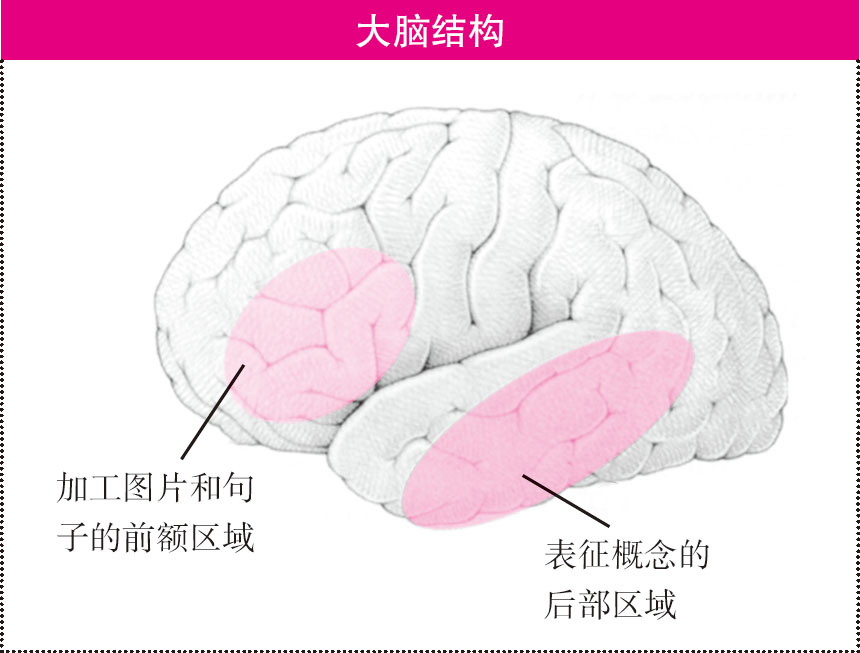

图5.1 与意义加工和概念表征有关的皮层区域。

虽然我们会谈到信息加工及其涉及脑区的神经科学证据，但是最引人注目的证据来自于对人们在事件发生后的记忆或遗忘的行为研究。

◎脑的前部区域与加工事件的意义有关，而后部区域则与概念的表征有关。

## 对事件意义的记忆

### 言语信息的记忆

万纳（Wanner，1968）的一项实验揭示了人们能否准确记住句子中所用单词的条件。万纳让被试在实验室中听录音机播放的指导语。其中一组被试为提示组，指导语如下：

本测验的材料，包括指导语都在此录音中。认真听指导语，因为我们要测验你回忆指导语中特定句子的能力。

第二组被试没有听到这样的提示，所以他们不知道要认真逐字地记忆指导语。除此之外，两组的指导语都是相同的。在指导语的最后，呈现的是下列四个关键句子中的一个 <sup>(2)</sup> ：

1. When you score your results，do nothing to correct your answers but mark carefully those answers which are wrong.
2. When you score your results，do nothing to correct your answers but carefully mark those answers which are wrong.
3. When you score your results，do nothing to your correct answers but mark carefully those answers which are wrong.
4. When you score your results，do nothing to your correct answers but carefully mark those answers which are wrong.

上述句子中的一个句子出现后，所有被试（有提示组和无提示组）都会立即听到下面的结语：

现在开始测验，请翻开答题册的第二页，判断所给出的句子中哪一句出现在了你刚才听到的指导语中。

在第二页，他们会发现刚刚听到的关键句子以及一个相似的选项。假设他们听到的是句子1。他们可能要在句子1和2或者句子1和3中进行选择。每对选项都只在两个词的顺序上有差异。但是，句子1和2之间在意义上没有差别；只是在措词方式上不同。而句子1和3很明显在意义上不同。因此，通过考察被试分辨这两对句子之间差异的能力，万纳就能够测量他们记忆句子的意义与措词方式的能力，并且确定这种能力怎样受到是否被提示的影响。

相关数据结果如图5.2所示。正确再认听到的句子的比率与被试是否得到提示之间存在函数关系。图中分别给出了被试分辨措词的意义差异和分辨措词方式差异的正确率。如果被试单凭猜测，那么他们的回答也可能有50％的正确率；因此，我们预期不会有低于50％的正确率。

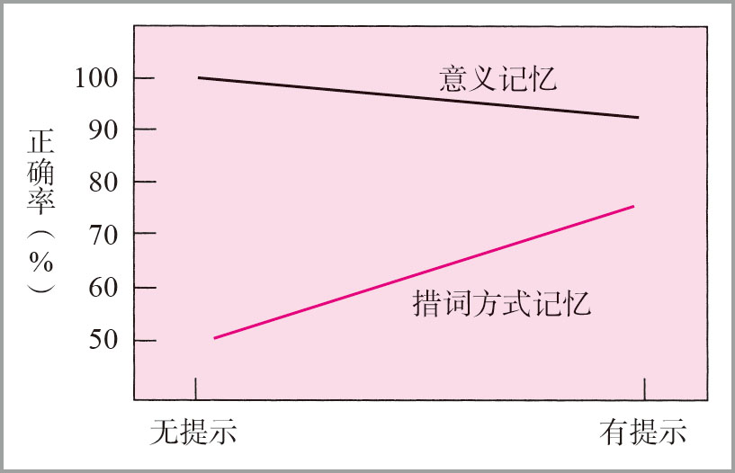

图5.2 万纳的实验考察了人们能否准确记住词语的条件，结果如图所示。被试记住导致意义差别或措词方式差别的单词的能力与是否听到随后要求回忆特定句子的提示之间存在函数关系。 （After Wanner，1968．Adapted by permission of the author.）

万纳实验的意义是显而易见的。首先，对措词改变导致意义变化的记忆要好于仅是措词方式的变化。记忆对意义的加工优势表明人们通常能够从语言信息中提取意义，但不会记住确切的措词。此外，无论人们是否得到提示，对意义的记忆效果都同样好。（无提示组被试的正确率稍高一点，但是未达到统计上的显著性。）因此，记住信息的意义是正常理解加工的一部分。他们并不需要“记住句子”的提示。

◎加工言语信息之后，人们通常仅记住了它的意义而不会记住确切的措词。

### 视觉信息记忆

很多情况下，我们对图片或场景等视觉信息的记忆能力似乎强于言语信息（无论言语信息以听觉方式呈现还是以视觉方式呈现）。谢帕德（Shepard，1967）报告了一个实验，他让被试学习一组杂志图片，一次只看一幅。然后再给被试呈现成对的图片，其中的一幅图片是学习过的，另一幅是没学过的。被试的任务是再认学习过的图片。这一任务与另一个言语条件任务进行比较。类似地，在言语条件任务中被试先学习句子，测验阶段给被试看成对的句子，其中一个句子是学习过的而另一个是没学过的，让被试再认学过的句子。被试在句子条件下的错误率为11.8％，但是在图片条件下的错误率只有1.5％。换句话说，对句子的再认记忆已经是相当好了，而对图片的再认则堪称完美。谢帕德的实验使用了600幅图片，后来有许多人也做了类似的实验。其中最令人印象深刻的视觉记忆实验是斯坦丁（Standing，1973）所做的，被试学习了10000幅图片，但再认的错误率却只有17％。

虽然人们在某些情境中记忆图片的能力很强，但是他们记住的似乎是图片的某种解释而不是确切的图片本身。也就是说，区分图片的含义与物理图片本身是非常必要的，正如区分句子的意义与句子本身很重要一样。有许多实验表明了图片记忆中这类区分的作用以及我们倾向于记住图片的意义，而非图片本身的事实。

以曼德勒和里奇（Mandler & Ritchey，1977）的实验为例。他们让被试学习一些场景中的图片，如图5.3中的教室。每幅图片学习10秒，共学习了八幅图片，之后测验被试的再认记忆。给被试呈现一系列图片，并让他们指出哪些是学过的。测验图片中既有先前学习过的也有干扰图片。一种干扰如图5.3b所示，称为表面性干扰（token distracter）。它与目标刺激的差别只在于老师衣服的图案，这是对图片的主要意义相对不重要的视觉细节。另一种干扰如图5.3c所示，相比之下，它具有特征性变化（type change），老师使用的世界地图变成了艺术作品。该视觉细节信息关系着对图片的大多数解释，因为它反映了老师所讲授的科目。给被试看的所有八幅图片都既有表面性变化又有特征性变化。特征性变化对图片含义的影响比表面性变化大。而特征性变化和表面性变化在物理变化的程度上并没有系统的差异。被试能够再认出77％的原始图片，正确拒绝的表面性干扰图片只有60％，但是他们正确拒绝的特征性干扰图片达到94％。

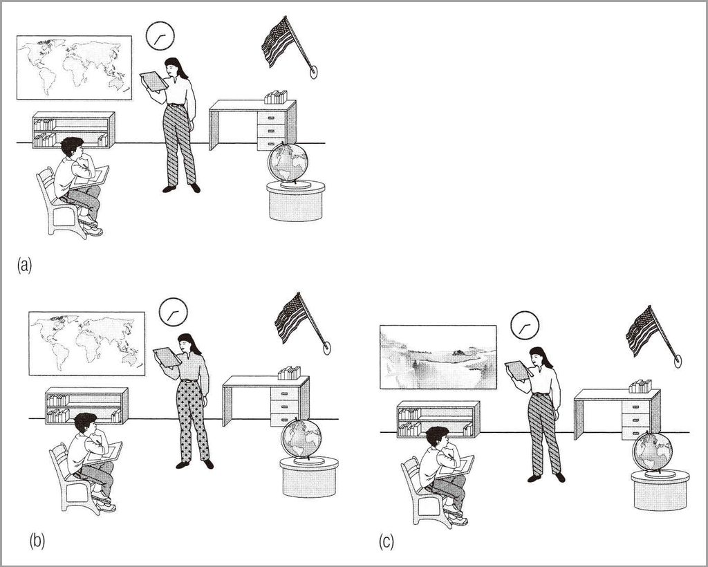

图5.3 与曼德勒和里奇的实验材料类似的图片，这个实验想要考察人们对图片含义和物理图片本身的分辨情况。被试学习目标图片（a）。随后他们在测验中会看到一系列图片，其中包括目标图片（a），也包括表面性干扰图片（b）和特征性干扰图片（c）。 （资料来源：Mandler & Ritchey，1977．Adapted by permission of the publisher．© 1977 by the American Psychological Association.）

这个研究的结论与前面讨论的万纳（Wanner，1968）的实验结果非常相似。万纳发现被试对句子的意义变化更为敏感。曼德勒和里奇（Mandler and Ritchey，1977）发现被试对图片含义的变化更为敏感。或许人们对图片含义比对句子含义的记忆更牢，但是对于两者的物理细节却没那么容易记住。

鲍尔等人（Bower，Karlin，& Dueck，1975）报告了一个有趣的事实，人们对图片的良好记忆与他们对那些图片的解释有关。图5.4所示的是他们使用的一些材料。这些研究者让被试学习一些被称为组多图（droodles） <sup>(3)</sup> 的图形，呈现或不呈现图形意义的解释。在随后的记忆测验中，被试要重新画出这些图形。如果被试在学习阶段被告知了图形解释，那么他们对这些图形的回忆效果（70％的重画准确率）比那些没有被告知图形解释的被试（51％的重画准确率）要好。因此，被试对这些图形的记忆非常依赖于其赋予这些图形意义的能力。

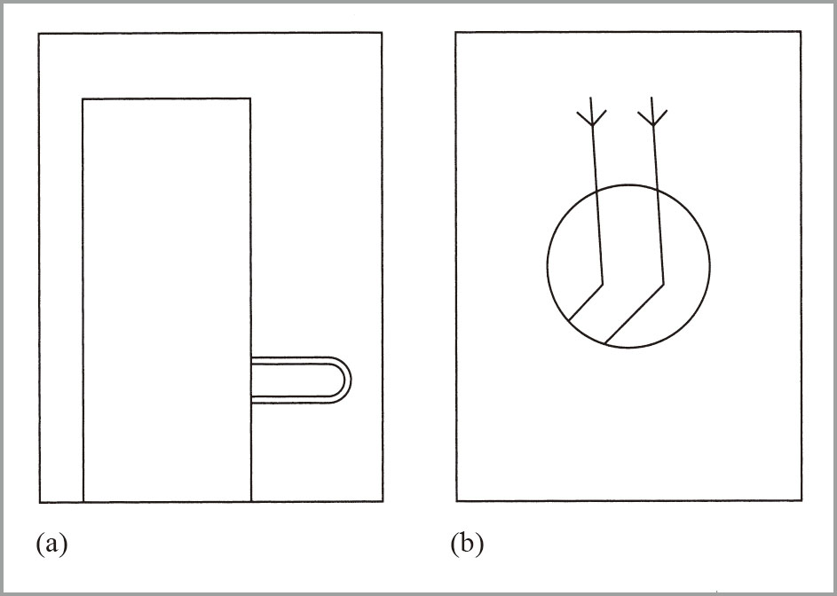

图5.4 回忆“组多图”。（a）一个小矮人在电话亭里吹长号。（b）早起的鸟儿抓到了一只非常壮硕的虫子。 （资料来源：Bower，Karlin，& Dueck，1975．Reprinted by permission of the publisher．© 1975 by Memory & Cognition .）

◎当人们看一幅图画时，他们倾向于记住这幅图画的意义。

### 细节与意义的保持

有证据表明人们开始时能够编码一个句子或一幅图片的许多知觉细节，但是很快就会把这些信息遗忘。一旦知觉信息被遗忘，人们就只保留了对图片解释的记忆。图片的方向属于一种视觉细节，对它的记忆似乎消退得非常快，格恩斯巴赫（Gernsbacher，1985）的实验证实了这一点。给被试看如图5.5中的图片。在学习过其中一幅图片后，让被试判断一对图片中哪个是刚才看过的。在10秒钟后，被试判断的正确率为79％，表明他们较好地保持了左-右方向的信息。但是，在10分钟后，他们判断的正确率降为57％（50％意味着随机猜测）。而另一方面，此时，他们对这幅图画意义的记忆仍保持得很好。

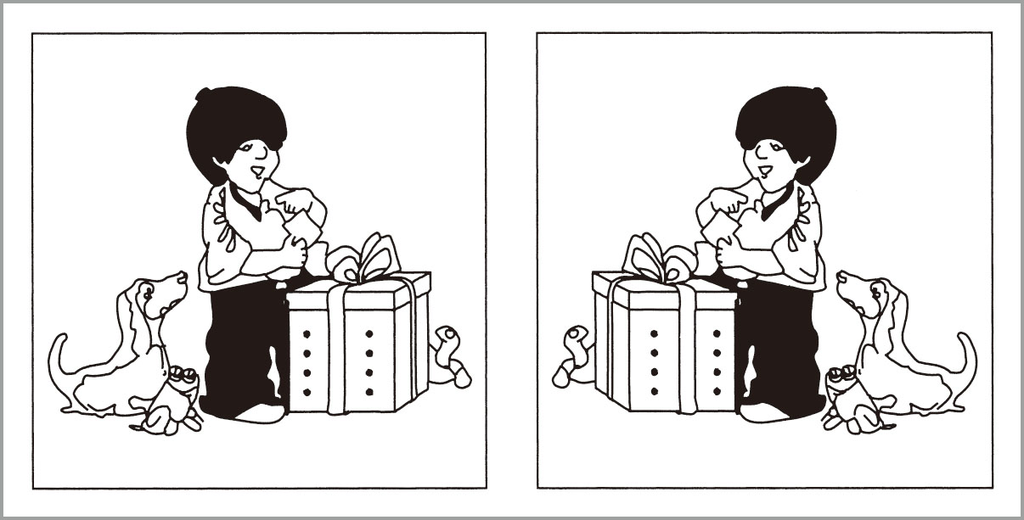

图5.5 格恩斯巴赫的实验中所使用图片的例子，其中一幅图片的方向是向左，另一幅的方向恰好相反（向右）。实验表明对图片方向的记忆是一种消退很快的视觉细节。 （资料来源：Gernsbacher，1985．Original illustration from Mercer and Mariana Meyer，One Frog Too Many．© 1975 by Mercer and Mariana Meyer．Reprinted by permission of the publisher．Dial Books for Young Readers．New York.）

在读研究生时，我做过一个言语领域内的实验（Anderson，1974b），得出了同样的结论。被试听一个故事，故事中包含的各种关键句子将在测验中出现，例如：

传教士射杀了画家。

随后，给被试呈现下列句子中的一个，并问被试该句子在逻辑上是否符合所听到的故事。他们还要判断哪个句子是他们真正听到的。

1. 传教士射杀了画家。
2. 画家被传教士射杀了。
3. 画家射杀了传教士。
4. 传教士被画家射杀了。

在逻辑判断中前两个句子应当是正确的，而后两个应当是错误的。被试或者在听到句子后立即接受测验，或者在2分钟以后接受测验。延迟测验对逻辑判断（例如，在1和3中选择）的准确率几乎没有影响。立即测验的正确率为98％，延迟测验的正确率为96％。但是当让被试判断哪个是他们听到的句子时（例如，在1和2中选择），延迟效应非常显著。被试在听到句子后立即接受测验，正确率达到99％，但是延迟后的正确率只有56％。

◎一开始能记住细节，但是很快就会遗忘，而对意义的记忆则能够保持。

### 意义记忆效果好的启示

我们已经看到人们对信息意义的记忆效果相对较好。所以当面对需要记住的材料时，如果赋予它一些有意义的解释就可以帮助记忆。不幸的是，许多人没有意识到这一事实，他们的记忆效果也因此很糟糕。我至今还记得我在第一次配对联想实验中的创伤性经验。事情发生在大学二年级时的实验心理学课堂上。其中的缘由我早已忘记了，只记得我们设计了一个课堂实验，实验要求学习16对材料，例如DAX-GIB。我们的任务是当出现前半部分时，回忆出后半部分。我一心想要胜过班上的其他同学。当时我个人奉行的记忆理论是如果你努力去做、集中精神，你就能牢牢地记住任何事。在临近实验的时候，也就是说在学习阶段我应该反复复述（声音越大越好）配对材料，而且要尽可能快。我相信这个方法能够将配对材料永远刻在我的心中。令我懊恼的是，我的成绩是全班最差的。

我的“大声加快速”的理论与促进记忆的正确手段恰好相反。我在努力记住无意义的配对文字。但是本章所讨论的材料证明我们对有意义信息有最好的记忆。我应该尝试将记忆任务转化为一些有意义的事情。例如，DAX看起来像dad （爸爸 ），而GIB是gibberish （胡言乱语 ）的前半部分。所以我可以创造一个爸爸正在对我胡言乱语的景象。这是一种简单的记忆术 （mnemonic technique），并且是非常好用的把两个事物联系起来的方法。

在实验室外我们通常不需要学习成对的无意义音节。但是，在许多情境下，我们不得不将许多没什么内在含义的东西联系起来。我们必须记住购物清单、不同长相的人的名字、电话号码、课程中需要记的东西、外语单词等等。在所有这些情况下，如果我们赋予将要记忆的东西一定的意义，那么就能够提高记忆力。

◎如果将随意的组合转换为有意义的东西，记忆起来就会比较容易。

### 启示

#### 记住词汇表的记忆术

在背外语词汇表的时候，我们似乎不得不学习随意的组合。例如，努力学习意大利语formaggio （读作“for modge jo”）的意思是奶酪。有的学生学过或者自己发现了一种学习词汇表的方法，称为关键词法。第一步是将外语单词转换成母语中发音相近的词。例如，可以将formaggio 转换成“for much dough”（好多钱）。第二步是建立相近的发音和词义之间的有意义的关联。例如我们可以想象价格昂贵的奶酪卖得好贵，“for much dough”。再以意大利语carciofi 为例，其意思是洋蓟（artichoke）。我们可以将其发音从“car-choh-fee”转换为“cat-trophy”（赛车-奖杯），并想象车展上一辆获胜的赛车和一个洋蓟形状的奖杯。中介词（例如，for much dough或car trophy）就称为关键词，虽然在上述例子中它们实际上都是关键短语。人们对这种方法的有效性进行了广泛研究（综述见Kroll & DeGroot，2005）。研究显示，像许多事物一样，我们需要一种细致的方法来评价关键词技术的有效性。毫无疑问，关键词法在许多情境下都会提高学习词汇表的速度，但是也会付出潜在的代价。可以想象，必须借助的中介关键词降低了翻译速度，而且在提取时间上关键词技术也慢于不借助中介词的直接提取。另外，有人或许会怀疑中介词对长期记忆的影响，并且的确有结果表明它不利于记忆的长期保持。最后，有证据显示，虽然这种方法有助于通过课堂上即时的词汇测验，对我们还未涉及的延时测验有不良影响，但是它对实际语言掌握的影响微乎其微。第12章将讨论外语学习方面的内容。

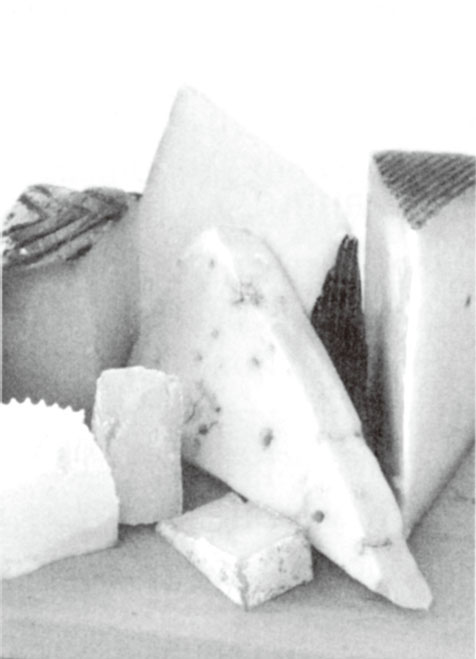

## 命题表征

我们已经看到，在很多情况下，人们记住的不是他们所见所闻的精确物理细节，而是其中的“意义”。为了能确切地把握何为“意义”，认知心理学家提出了命题表征 （propositional representation）。来自逻辑学和语言学的命题 （proposition）的概念是这种分析的核心。命题是可作为独立断言的最小的知识单元。也就是说，命题是能够从意义上判断出是真是假的最小单元。命题分析最常见于语言学信息，这里将根据这些信息深入探讨该主题。

考虑下面的句子：

残酷战争时期的美国总统林肯解放了奴隶们。（Lincoln，who was president of the United States during a bitter war，freed the slaves.）

这个句子传达的信息可以由以下较简单的句子来表达：

A．林肯是南北战争时期的美国总统。（Lincoln was president of the United States during a war.）

B．战争是残酷的。（The war was bitter.）

C．林肯解放了奴隶们。（Lincoln freed the slaves.）

如果这些简单句中的任何一个为假，那么复合句也为假。这些句子准确地对应着构成该复合句意义的基础命题。每个简单句都表达了一个基本的意义单元。我们的意义表征必须满足的一个条件是，构成它的每个独立单元都必须对应于一个意义单元。

但是，命题表征理论并不认为一个人会记住上面这些简单句子。已有的研究显示，人们对这些简单句的确切措词的记忆并不比对原本的复合句的确切措词的记忆来得强。例如，在我读研究生期间所做的另一项研究中（Anderson，1972），我发现被试很难记住他们听到的是句子C还是下面的句子：

奴隶们是被林肯解放的。（The slaves were freed by Lincoln.）

因此，我们记忆中的信息表征似乎只保存基本命题的意义，而不会保存任何具体措词信息。许多命题符号系统都用这种抽象的方式表征信息。金西（Kintsch，1974）所使用的一种方法是将每个命题表征成一个列表，它包含了关系 （relation）及依关系而有序排列的若干项 （argument）。关系将各项组织起来，它通常对应着动词（在这个例子中是解放 ）、形容词（残酷 ）和其他的关系词（……的总统 ，president-of）。项是指特定的时间、地点、人物或物体等，通常对应着名词（如：林肯、战争、奴隶 ）。关系指出这些名词所指实体之间的联系。金西用有括号的由一个关系和若干项构成的列表来表征这些命题。例如，从句子A到C可以用如下的列表来表征：

1. （……的总统：林肯，美国，战争）
2. （残酷：战争）
3. （解放：林肯，奴隶们）

注意，每种关系下有不同数目的项：……的总统 有三个，解放 有两个，残酷 有一个。无论一个人听到原本的复合句，还是听到

奴隶们被残酷战争时期的美国总统林肯解放了。（The slaves were freed by Lincoln，the president of the United States during the bitter war.）

它们所传达的意义都是由从a到c的列表来表征的。

布兰斯福德和弗兰克斯（Bransford & Franks，1971）为命题单元的心理学真实性提供了有趣的证据。在这个实验中，被试学习12个句子，包括以下这些：

蚂蚁吃桌子上面的甜果冻。

岩石滚下山来砸坏了小房子。

厨房里面的蚂蚁吃果冻。

岩石滚下山来砸坏了树林旁边的小房子。

厨房里面的蚂蚁吃桌子上面的果冻。

小房子坐落在树林旁边。

果冻是甜的。 <sup>(4)</sup>

所有这些句子都由两个命题组中的命题构成，每组各有四个命题。其中一组的四个命题如下：

1. （吃：蚂蚁，果冻，过去时） <sup>(5)</sup>
2. （甜的：果冻）
3. （上面：果冻，桌子，过去时）
4. （里面：蚂蚁，厨房，过去时）

另一组的四个命题如下：

1. （滚下：岩石，山，过去时）
2. （砸坏：岩石，房子，过去时）
3. （旁边：房子，树林，过去时）
4. （小：房子）

布兰斯福德和弗兰克斯测试了被试对下面三类句子的再认记忆：

1. 旧的：厨房里面的蚂蚁吃果冻。
2. 新的：蚂蚁吃甜的果冻。
3. 无关的：蚂蚁吃树林旁边的果冻。

第一类句子确实是学习过的，第二类句子没有学过，但是是由学习过的相关命题组合成的，而第三类句子由学习过的单词组成而不是学习过的命题。布兰斯福德和弗兰克斯发现，被试几乎无法分辨前两类句子，他们以相同的可能性认为这些句子是真的听过。另一方面，被试非常确信他们没有听过第三类无关的句子。

实验表明，虽然人们记住了他们学过的命题，但是他们对于命题的确切组合并不敏感。事实上，该实验中的被试最有可能报告说他们听到了一个包含所有四个命题的句子，例如：

厨房里面的蚂蚁吃桌子上面甜甜的果冻。

尽管他们事实上并没有学过这个句子。

◎根据命题分析，人们在记忆一个复合句时，会将句子分解成一组表征句子中的简单命题的抽象意义单元。

### 命题网络

在认知心理学文献中，人们有时会发现用网络形式表征的命题。图5.6表示的是一个命题网络 （propositional network）的例子，它对“残酷战争时期的美国总统林肯解放了奴隶们”这个句子进行了编码。在这个命题网络中，每个命题都由一个椭圆形表示，它通过箭头与关系和项相连接。这些命题、关系和项被称为网络的节点 （nodes），而箭头被称为连接 （link），因为它把节点连了起来。例如，图5.6a中的椭圆形表示前面金西所分析的命题（a）。椭圆形由标记着关系 的箭头线（标明它是指向关系节点的）连接着关系……的总统 ，由标记为施动者 的箭头线连接着林肯 ，由标记为对象 的箭头线连接着美国 ，还由标记为时间 的箭头线指向战争 。图5.6a、图5.6b和图5.6c所示的三个网络结构分别表征了前面金西所分析的从（a）到（c）的命题。注意，三个网络中含相同的节点。例如，图5.6a和图5.6b中都有战争 。这种重叠表明，这些网络实际上是图5.6d所示的一个更大网络中相互联系的部分。这最后一个网络表征了第134页中原复合句中所有的有意义信息。

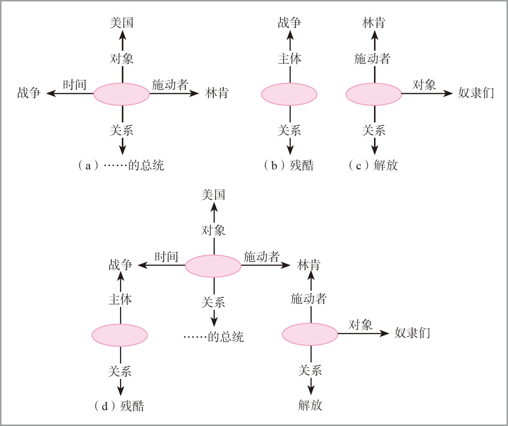

图5.6 “残酷战争时期的美国总统林肯解放了奴隶们”这一陈述的基础命题的网络表征。

网络中元素的空间位置与它们的意义无关。网络可以看作是用绳子连结在一起的若干玻璃球。玻璃球表示节点，绳子表示节点之间的连接。二维纸页上呈现的网络是缠结在一起的玻璃球以某种方式平铺开来。我们试图以便于理解的方式将网络平铺，但是平铺的方式可以有很多种。重要的是哪个元素与哪个元素连接在一起，而不是它们处于什么位置。

许多实验显示，以这种网络形式，将节点当作概念，将节点之间的连接当作概念之间的关联是非常有帮助的。考虑韦斯伯格（Weisberg，1969）使用了限制联想任务的实验。在实验中，被试学习并记忆这样的句子：“动作慢的小孩子吃的面包是凉的”。这个句子的命题网络表征如图5.7所示。在学习过一个句子之后，被试要完成自由联想任务。在任务中，呈现给被试句子中的一个单词要求他们回答脑中浮现的第一个句子中的单词。给被试的线索词是慢 时，他们几乎总是自由联想到小孩子 而不会想到面包 。尽管相比小孩子 ，面包 在句子中的位置离慢 更近。然而，在图5.7的网络中，慢 和小孩子 之间（两个连接）的距离比慢 和面包 之间（四个连接）的距离更近。类似地，给被试的线索词是面包 时，他们几乎总是回忆起凉 而不是慢 ，尽管在句子中面包 和慢 比面包 和凉 的距离更近。同样，在网络中面包 和凉 （两个连接）比面包 和慢 （四个连接）更接近。［拉特克利夫和麦克恩（R．A．Ratcliff & McKoon，1978）的实验得到了类似的结果。］

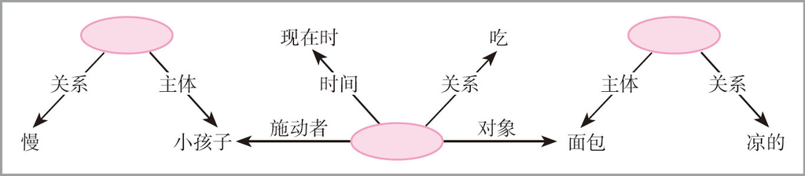

图5.7 句子“动作慢的小孩子吃的面包是凉的”的命题网络表征。韦斯伯格（Weisberg 1969）在一个实验中使用了这样的句子来证明，命题网络中词的接近性比词在句子中物理位置的接近性更能影响记忆。

◎命题信息可以由表示概念之间关系的网络来表征。